# **Facial Emotion Detection**

## **Problem Definition**

**The Context**

Facial emotion recognition/detection has the potential to revolutionize human-computer interaction (HCI) by enabling machines to understand human emotions. Even though our project focuses on Grayscale image classification but it is an important task in computer vision. Overall, this technology has applications in various fields:

- Customer Service: Systems can personalize interactions based on customer emotions, improving satisfaction and loyalty.
- Education: Educational tools can adapt to student frustration or confusion based on facial expressions.
- Healthcare: AI-powered systems can detect signs of depression or anxiety through facial cues, aiding in early diagnosis and intervention.
- Market Research: Analyzing facial expressions during product testing can provide deeper insights into consumer preferences.
- Security: Systems can identify potential security threats by recognizing aggression or deceit in facial expressions

**The Objectives**

The intended goal is to:

- Develop a model that can accurately classify grayscale images into different classes
- Explore and compare the performance of different deep learning models for image classification
- Identify the best model for the task and analyze its results by using plot visualization, classification report, and confusion matrix

**The Key Questions**

The key questions that need to be answered are:

- Which deep learning models are most effective for facial emotion recognition especially for grayscale image classification?
- What data preprocessing techniques are necessary for optimal model performance?
- How can we address challenges like variations in facial features and lighting conditions?
- How do different models compare in terms of accuracy and performance?
- What are the key factors that contribute to the success of the chosen model?

**The Problem Formulation**

We are trying to solve a multi-class image classification problem using data science, where:

- The input data consists of grayscale images
- The output is a categorical label representing the class of the image
- The goal is to leverage data science to develop a deep learning model that can accurately predict the class label for a given grayscale image.

## **About the dataset**

The data set consists of 3 folders, i.e., 'test', 'train', and 'validation'. Each of these folders has four subfolders (4 classes):

**‘happy’**: Images of people who have happy facial expressions.  
**‘sad’**: Images of people with sad or upset facial expressions.  
**‘surprise’**: Images of people who have shocked or surprised facial expressions.  
**‘neutral’**: Images of people showing no prominent emotion in their facial expression at all.

## **Mounting the Drive**

**NOTE:** Please use Google Colab from your browser for this notebook. **Google.colab is NOT a library that can be downloaded locally on your device.**

```python
# Import Drive library from Google Colab and then mount Google Drive
from google.colab import drive
drive.mount('/content/drive')
```

## **Importing the Libraries**

```python
import numpy as np
import pandas as pd
import matplotlib.pyplot as plt
import seaborn as sns

# Organize image processing libraries
from PIL import Image
import cv2
from tensorflow.keras.preprocessing.image import ImageDataGenerator, load_img

# Organize file handling libraries
import os
from pathlib import Path  # For cleaner path handling
import zipfile  # For unzipping

# Organize deep learning libraries
from tensorflow.keras import regularizers, optimizers
from tensorflow.keras.regularizers import l2
from tensorflow.keras.models import Sequential
from tensorflow.keras.layers import Conv2D, Dense, Dropout, Flatten, MaxPooling2D, GaussianNoise, BatchNormalization, Activation, LeakyReLU
from tensorflow.keras.models import Model
from tensorflow.keras.applications import ResNet50V2, VGG16, EfficientNetV2B2  # For transfer learning
from tensorflow.keras.optimizers import Adam
from tensorflow.keras.losses import categorical_crossentropy
from keras.callbacks import ModelCheckpoint, EarlyStopping, ReduceLROnPlateau
from tensorflow.keras.preprocessing import image

# Organize data preprocessing libraries (if needed later)
from sklearn.preprocessing import LabelEncoder, OneHotEncoder, StandardScaler, MinMaxScaler
from sklearn.model_selection import train_test_split
from sklearn.metrics import confusion_matrix, classification_report, accuracy_score, precision_score, recall_score, f1_score

from tqdm import tqdm  # For progress bar

# Suppress warnings
import warnings
warnings.filterwarnings('ignore')
```

### **Let us load and unzip the data**

**Note:**

- You must download the dataset from the link provided on Olympus and upload the same on your Google drive before executing the code in the next cell.
- In case of any error, please make sure that the path of the file is correct as the path may be different for you.

```python
# Define constants for data handling
ZIPPED_PATH = Path('/content/drive/MyDrive/ML-DL-AI/ML-DL-AI_Courses/MIT-ADSP_Mar2024/Capstone-Project/Facial_emotion_images.zip')
DATA_PATH = Path('/content/Facial_emotion_images')
IMG_SIZE = 48
```

```python
# Unzip the dataset
with zipfile.ZipFile(ZIPPED_PATH, 'r') as zip_ref:
    zip_ref.extractall()
```

```python
# List sub-diretcories within the unzipped dataset
print(os.listdir(DATA_PATH))
```

```
['train', 'test', 'validation']
```

```python
# Create variables for sub-directories in the DATA_PATH for later use
test_dir = DATA_PATH / 'test'
train_dir = DATA_PATH / 'train'
validation_dir = DATA_PATH / 'validation'
```

## **Visualizing our Classes**

Let's look at our classes.

**Write down your observation for each class. What do you think can be a unique feature of each emotion, that separates it from the remaining classes?**

```python
def show_facial_emotion(emotion):
    train_emotion = train_dir / emotion
    images = os.listdir(train_emotion)
    if not images:
        print(f"No images found in {train_emotion}")
        return
    images = [Image.open(os.path.join(train_emotion, img)) for img in images[:15]]
    plt.figure(figsize=(10, 8))
    plt.suptitle(f"First 15 images with a {emotion.capitalize()} Face", fontsize=16)
    plt.subplots_adjust(top=0.95, wspace=0.3)

    for i in range(len(images)):
        plt.subplot(3, 5, i+1)
        plt.imshow(images[i], cmap='gray')
    plt.show()
```

### **Happy**

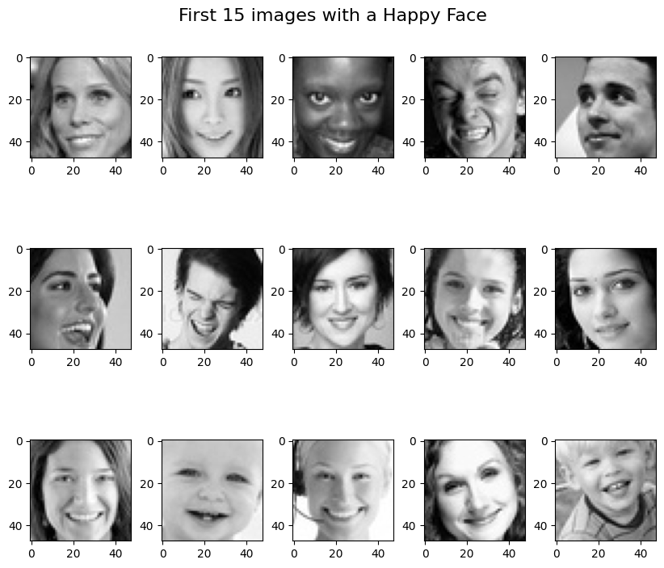

```python
# Let's display first 15 images with the emotion of a Happy face by calling the show_facial_emotion funciton with "happy" argument.
show_facial_emotion('happy')
```

**Observations and Insights:__** Below are some of the observations while looking at the images labeled ""Happy" above in the output.

- We see diversity where people of different ages, colors, and races are shown.
- Most of the pictures are with smiles though excitement differs from a person to person.
- We see photos taken from different angles and from different distances. We'll leverage data augmentation to cover different different angle for example to predict correctly the images that are a little side-wise.
- Some pcitures are cropped and need to be taken care of during data augmentation.
- We can see that pictures have different brightness levels and to be taken care of with the help of data augmentation.
- Some pictures may nto really be interpreted as "happy" by a human being in real world such as image-4 from left in row-1. Hence, Model accuracy may not be perfect as we cannot modify the dataset and re-label them.
- We can clearly see that the images are of grayscale (most of them if not all in the whole dataset). Hence, models trained with "Grayscale" images may have better accuracies and less losses that the models trained with RGB images. We need to have Image generators for each dataset for each color_mode (RGB and Grayscale).

### **Sad**

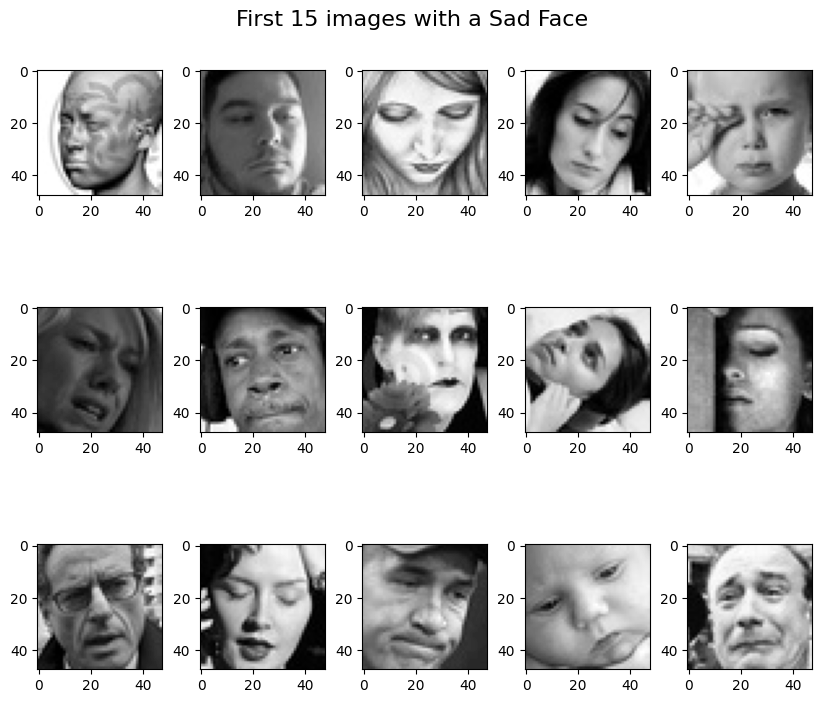

```python
# Now, let's display first 15 images with the emotion of a Sad face
show_facial_emotion('sad')
```

- We can drive almost same observations as we did for "Happy" class that images represent diversity and have different brightnes levels, zoom levels, camera angles, and also some may not really be interpreted as "Sad" e.g. row-2 image-3 (from left), row-3 image-1 and image-4 (especially, baby may not really be sad).
- We also can observe that some of the images are partially covered and not fully shown e.g. row-1 image-5 and row-2 image-5 etc. Hence, Model accuracy may not be too good.

### **Neutral**

[figure not shown]

```python
# Now, let's display first 15 images with the emotion of a Neutral face
show_facial_emotion('neutral')
```

**Observations and Insights:__**

- We can drive almost same observations as we did for "Happy" class that images represent diversity and have different brightnes levels, zoom levels, camera angles, and also some may not really be interpreted as "Neutral" e.g. row-1 image-3 and image-4.
- We can observe that some of the images are partially covered and not fully shown e.g. row-1 image-5 and row-2 image-5 etc. Hence, Model accuracy may not be too good.
- We can also observe that some images seem sketchy for example row-2 image-2 doesn't seem to be real and doesn't really have "Neutral" emotion.

### **Surprised**

[figure not shown]

```python
# Now, let's display first 15 images with the emotion of a Surprised face
show_facial_emotion('surprise')
```

**Observations and Insights:__**

- We can drive almost same observations as we did for "Happy" class that images represent diversity and have different brightnes levels, zoom levels, camera angles, and also some may not really be interpreted as "Neutral" e.g. row-3 image-1 and image-3, and image-5. But most images are are with "Surprised" face.
- We can observe that some of the images are partially covered and not fully shown. Hence, Model accuracy may not be too good. Image size is 48x48 pixels and we'll have to rescale them during data augmentations so that pixel values are normalized and will eventually help with better training.

## **Checking Distribution of Classes**

```python
# Get the count of images in each training folder
train_emotion_counts = {
    'Happy': len(os.listdir(os.path.join(train_dir, 'happy'))),
    'Sad': len(os.listdir(os.path.join(train_dir, 'sad'))),
    'Neutral': len(os.listdir(os.path.join(train_dir, 'neutral'))),
    'Surprise': len(os.listdir(os.path.join(train_dir, 'surprise')))
}

# Create a DataFrame from the emotion counts
train_df = pd.DataFrame(list(train_emotion_counts.items()), columns=['Emotions', 'Count'])

# Calculate the percentage column
total_train_images = train_df['Count'].sum()
train_df['Percentage'] = round((train_df['Count'] / total_train_images) * 100, 1)

# Display the DataFrame
print("Distribution of Images per their Facial Emotions:\n")
train_df
```

```
Distribution of Images per their Facial Emotions:
```

|  | Emotions | Count | Percentage |
| --- | --- | --- | --- |
| 0 | Happy | 3976 | 26.3 |
| 1 | Sad | 3982 | 26.4 |
| 2 | Neutral | 3978 | 26.3 |
| 3 | Surprise | 3173 | 21.0 |

```python
# Define the function to show Emotions countplot
def countpl(x, y):
    plt.figure(figsize=(7, 5))
    sns.barplot(x=x, y=y, palette='Set2')
    plt.title('Distribution of Images per their Facial Emotions')
    plt.xlabel('Emotions')
    plt.ylabel('Count')
    plt.xticks(rotation=45)
    plt.show()
```

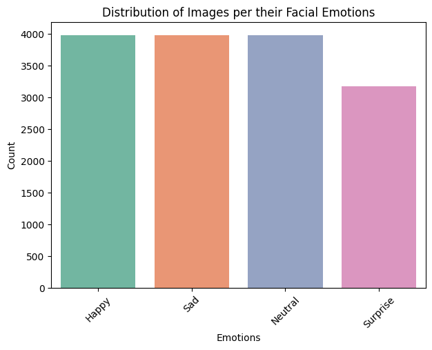

```python
# Call the countpl function to display count plot for training data
countpl(train_df['Emotions'], train_df['Count'])
```

```python
# Get the count of images in each training folder
validation_emotion_counts = {
    'Happy': len(os.listdir(os.path.join(validation_dir, 'happy'))),
    'Sad': len(os.listdir(os.path.join(validation_dir, 'sad'))),
    'Neutral': len(os.listdir(os.path.join(validation_dir, 'neutral'))),
    'Surprise': len(os.listdir(os.path.join(validation_dir, 'surprise')))
}

# Create a DataFrame from the emotion counts
validation_df = pd.DataFrame(list(validation_emotion_counts.items()), columns=['Emotions', 'Count'])

# Calculate the percentage column
total_validation_images = validation_df['Count'].sum()
validation_df['Percentage'] = round((validation_df['Count'] / total_validation_images) * 100, 1)

# Display the DataFrame
print("Distribution of Images per their Facial Emotions:\n")
validation_df
```

```
Distribution of Images per their Facial Emotions:
```

|  | Emotions | Count | Percentage |
| --- | --- | --- | --- |
| 0 | Happy | 1825 | 36.7 |
| 1 | Sad | 1139 | 22.9 |
| 2 | Neutral | 1216 | 24.4 |
| 3 | Surprise | 797 | 16.0 |

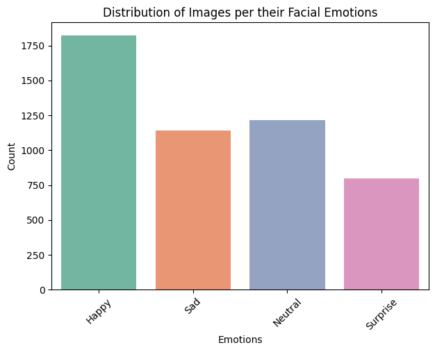

```python
# Call the countpl function to display count plot for training data
countpl(validation_df['Emotions'], validation_df['Count'])
```

```python
# Get the count of images in each training folder
test_emotion_counts = {
    'Happy': len(os.listdir(os.path.join(test_dir, 'happy'))),
    'Sad': len(os.listdir(os.path.join(test_dir, 'sad'))),
    'Neutral': len(os.listdir(os.path.join(test_dir, 'neutral'))),
    'Surprise': len(os.listdir(os.path.join(test_dir, 'surprise')))
}

# Create a DataFrame from the emotion counts
test_df = pd.DataFrame(list(test_emotion_counts.items()), columns=['Emotions', 'Count'])

# Calculate the percentage column
total_test_images = test_df['Count'].sum()
test_df['Percentage'] = round((test_df['Count'] / total_test_images) * 100, 1)

# Display the DataFrame
print("Distribution of Images per their Facial Emotions:\n")
test_df
```

```
Distribution of Images per their Facial Emotions:
```

|  | Emotions | Count | Percentage |
| --- | --- | --- | --- |
| 0 | Happy | 32 | 25.0 |
| 1 | Sad | 32 | 25.0 |
| 2 | Neutral | 32 | 25.0 |
| 3 | Surprise | 32 | 25.0 |

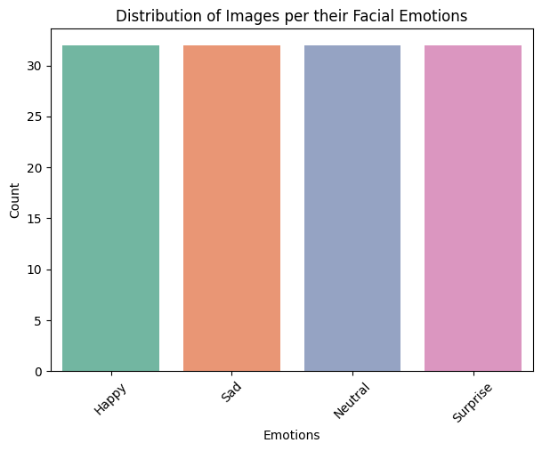

```python
# Call the countpl function to display count plot for training data
countpl(test_df['Emotions'], test_df['Count'])
```

**Observations and Insights:__**

- We can observe that there isn't much of difference of distribution of classes or emotions except of "Surprised" class where images are 21% of all of the images in the Training Dataset.
- Validation test has different distributions of the classes where most of the images belong to "Happy" class (36.7%) whereas "Suprised" class yet again has lower number of images (16%).
- We don't see exactly similar disctibution in Test datase where all of the classes of have 32 images (25% each).

**Think About It:**

- Are the classes equally distributed? If not, do you think the imbalance is too high? Will it be a problem as we progress?
- Are there any Exploratory Data Analysis tasks that we can do here? Would they provide any meaningful insights?

## **Creating our Data Loaders**

In this section, we are creating data loaders that we will use as inputs to our Neural Network.

**You have two options for the color_mode. You can set it to color_mode = 'rgb' or color_mode = 'grayscale'. You will need to try out both and see for yourself which one gives better performance.**

```python
# Data Augmentation
train_datagen = ImageDataGenerator(horizontal_flip = True,
                                                  brightness_range = (0.,2.),
                                                  rescale = 1./255,
                                                  shear_range = 0.3)

test_datagen = ImageDataGenerator(rescale = 1./255) # No data augmentation for test and/or validation data


# Image Generators -- Color Images (RGB)
print("RGB Colored Images:")

train_generator_rgb = train_datagen.flow_from_directory(
    train_dir,
    target_size=(IMG_SIZE, IMG_SIZE),
    batch_size=32,
    color_mode='rgb',
    class_mode='categorical', # One-hot encoding for multiple emotions
    shuffle=True
)

validation_generator_rgb = test_datagen.flow_from_directory(
    validation_dir,
    target_size=(IMG_SIZE, IMG_SIZE),
    batch_size=32,
    color_mode='rgb',
    class_mode='categorical',
    shuffle=False
)

test_generator_rgb = test_datagen.flow_from_directory(
    test_dir,
    target_size=(IMG_SIZE, IMG_SIZE),
    batch_size=32,
    color_mode='rgb',
    class_mode='categorical',
    shuffle=False
)

# Define the number of classes (emotions)
num_classes = len(train_generator_rgb.class_indices)
print("\nNumber of training classes for RGB Images:", num_classes)
print("Class Indices for RGB Images:", train_generator_rgb.class_indices)



# Create image generators -- Grayscale Images
print("\nGrayscale Images:")

train_generator_gray = train_datagen.flow_from_directory(
    train_dir,
    target_size=(IMG_SIZE, IMG_SIZE),
    batch_size=32,
    color_mode='grayscale',
    class_mode='categorical',
    shuffle=True
)

validation_generator_gray = test_datagen.flow_from_directory(
    validation_dir,
    target_size=(IMG_SIZE, IMG_SIZE),
    batch_size=32,
    color_mode='grayscale',
    class_mode='categorical',
    shuffle=False
)

test_generator_gray = test_datagen.flow_from_directory(
    test_dir,
    target_size=(IMG_SIZE, IMG_SIZE),
    batch_size=32,
    color_mode='grayscale',
    class_mode='categorical',
    shuffle=False
)

# Define the number of classes (emotions)
num_classes_gray = len(train_generator_gray.class_indices)
print("\nNumber of training classes for Grayscale Images:", num_classes)
print("Training Class Indices for Grayscale Images:", train_generator_gray.class_indices)
```

```
RGB Colored Images:
Found 15109 images belonging to 4 classes.
Found 4977 images belonging to 4 classes.
Found 128 images belonging to 4 classes.

Number of training classes for RGB Images: 4
Class Indices for RGB Images: {'happy': 0, 'neutral': 1, 'sad': 2, 'surprise': 3}

Grayscale Images:
Found 15109 images belonging to 4 classes.
Found 4977 images belonging to 4 classes.
Found 128 images belonging to 4 classes.

Number of training classes for Grayscale Images: 4
Training Class Indices for Grayscale Images: {'happy': 0, 'neutral': 1, 'sad': 2, 'surprise': 3}
```

**Observations:**

Count for both grayscale and RGB images is same for each dataset type. As we saw that all of the images in the first 15 images in each dataset were grayscale. Hence, we can confidentaly say that all of the images are **Grayscale** and models trained with "RGB" color_made will not perform better.

Below is the distribution of images per dataset.

Training Data Images Count: **15109**

Validation Images Count: **4977**

Test Images Count: **128**

## **Model Building**

**Think About It:**

- Are Convolutional Neural Networks the right approach? Should we have gone with Artificial Neural Networks instead?
- What are the advantages of CNNs over ANNs and are they applicable here?

### **Creating the Base Neural Network**

Let's create a simple custom CNN Model as cnn_model_1 and compile and train the model to see the results of this architecture first. We'll use "Grayscale" images with input shape of (48, 48, 1) for this first base model.

```python
cnn_model_1 = Sequential([
    # Convolutional Layer-1
    Conv2D(32, (3, 3), activation='relu', input_shape=(IMG_SIZE, IMG_SIZE, 1), padding='same'),
    BatchNormalization(),
    MaxPooling2D((2, 2)), # MaxPooling Layer
    Dropout(0.3),  # Dropout layer to prevent overfitting

    # Convolutional Layer-2
    Conv2D(64, (3, 3), activation='relu', padding='same'),
    BatchNormalization(),
    MaxPooling2D((2, 2)),
    Dropout(0.4),

    # Convolutional Layer-3
    Conv2D(128, (3, 3), activation='relu', padding='same'),
    BatchNormalization(),
    MaxPooling2D((2, 2)),
    Dropout(0.5),

    Flatten(),  # Flatten the output of the convolutional layers

    Dense(128, activation='relu'),  # Dense (fully connected) hidden layer
    Dense(num_classes_gray, activation='softmax')  # Output layer: Classifier
])

# Model summary
cnn_model_1.summary()
```

```
Model: "sequential_13"
_________________________________________________________________
 Layer (type)                Output Shape              Param #
=================================================================
 conv2d_43 (Conv2D)          (None, 48, 48, 32)        320

 batch_normalization_25 (Ba  (None, 48, 48, 32)        128
 tchNormalization)

 max_pooling2d_43 (MaxPooli  (None, 24, 24, 32)        0
 ng2D)

 dropout_48 (Dropout)        (None, 24, 24, 32)        0

 conv2d_44 (Conv2D)          (None, 24, 24, 64)        18496

 batch_normalization_26 (Ba  (None, 24, 24, 64)        256
 tchNormalization)

 max_pooling2d_44 (MaxPooli  (None, 12, 12, 64)        0
 ng2D)

 dropout_49 (Dropout)        (None, 12, 12, 64)        0

 conv2d_45 (Conv2D)          (None, 12, 12, 128)       73856

 batch_normalization_27 (Ba  (None, 12, 12, 128)       512
 tchNormalization)

 max_pooling2d_45 (MaxPooli  (None, 6, 6, 128)         0
 ng2D)

 dropout_50 (Dropout)        (None, 6, 6, 128)         0

 flatten_17 (Flatten)        (None, 4608)              0

 dense_48 (Dense)            (None, 128)               589952

 dense_49 (Dense)            (None, 4)                 516

=================================================================
Total params: 684036 (2.61 MB)
Trainable params: 683588 (2.61 MB)
Non-trainable params: 448 (1.75 KB)
_________________________________________________________________
```

### **Compiling and Training the Model**

```python
# Creating a checkpoint which saves model weights from the best epoch
checkpoint = ModelCheckpoint("./cnn_model_1.h5", monitor='val_accuracy', verbose=1, save_best_only=True, mode='auto')

# Initiates early stopping if validation loss does not continue to improve
early_stopping = EarlyStopping(monitor = 'val_loss',
                          min_delta = 0,
                          patience = 5,
                          restore_best_weights = True
                          )

# Initiates reduced learning rate if validation loss does not continue to improve
reduce_learningrate = ReduceLROnPlateau(monitor = 'val_loss',
                              factor = 0.2,
                              patience = 3,
                              min_delta = 0.0001)

callbacks_list = [early_stopping, checkpoint, reduce_learningrate]
```

```python
# Compile the model with Adam optimizer
cnn_model_1.compile(optimizer=Adam(learning_rate=0.001), loss='categorical_crossentropy', metrics=['accuracy'])
```

```python
history_cnn1 = cnn_model_1.fit(
    train_generator_gray,
    epochs=20,
    validation_data=validation_generator_gray,
    callbacks=callbacks_list,
    verbose=1
)
```

```
Epoch 1: val_accuracy improved from -inf to 0.38979, saving model to ./cnn_model_1.h5
Epoch 2: val_accuracy improved from 0.38979 to 0.51838, saving model to ./cnn_model_1.h5
Epoch 3: val_accuracy improved from 0.51838 to 0.57042, saving model to ./cnn_model_1.h5
Epoch 4: val_accuracy improved from 0.57042 to 0.61181, saving model to ./cnn_model_1.h5
Epoch 5: val_accuracy did not improve from 0.61181
Epoch 6: val_accuracy improved from 0.61181 to 0.66164, saving model to ./cnn_model_1.h5
Epoch 7: val_accuracy improved from 0.66164 to 0.67330, saving model to ./cnn_model_1.h5
Epoch 8: val_accuracy did not improve from 0.67330
Epoch 9: val_accuracy improved from 0.67330 to 0.67973, saving model to ./cnn_model_1.h5
Epoch 10: val_accuracy did not improve from 0.67973
Epoch 11: val_accuracy improved from 0.67973 to 0.69339, saving model to ./cnn_model_1.h5
Epoch 12: val_accuracy did not improve from 0.69339
Epoch 13: val_accuracy improved from 0.69339 to 0.69419, saving model to ./cnn_model_1.h5
Epoch 14: val_accuracy did not improve from 0.69419
Epoch 15: val_accuracy improved from 0.69419 to 0.70424, saving model to ./cnn_model_1.h5
Epoch 16: val_accuracy did not improve from 0.70424
Epoch 17: val_accuracy did not improve from 0.70424
Epoch 18: val_accuracy did not improve from 0.70424
Epoch 19: val_accuracy improved from 0.70424 to 0.71730, saving model to ./cnn_model_1.h5
Epoch 20: val_accuracy improved from 0.71730 to 0.72132, saving model to ./cnn_model_1.h5
```

### **Evaluating the Model on the Test Set**

```python
# Evaluate the CNN Model 1 (Grayscale)

print("Accuracy and Loss values -- Test Data")
cnn1_test_loss, cnn1_test_accuracy = cnn_model_1.evaluate(test_generator_gray)
print(f'Test Accuracy: {cnn1_test_accuracy:.3f}, Test Loss: {cnn1_test_loss:.3f}')

print("\nAccuracy and Loss values -- Validation Data")
cnn1_val_loss, cnn1_val_accuracy = cnn_model_1.evaluate(validation_generator_gray)
print(f'Validation Accuracy: {cnn1_test_accuracy:.3f}, Validation Loss: {cnn1_test_loss:.3f}')
```

```
Accuracy and Loss values -- Test Data
Test Accuracy: 0.766, Test Loss: 0.622

Accuracy and Loss values -- Validation Data
Validation Accuracy: 0.766, Validation Loss: 0.622
```

```python
# Extract training and validation accuracy/loss from history
train_acc = history_cnn1.history['accuracy']
val_acc = history_cnn1.history['val_accuracy']

train_loss = history_cnn1.history['loss']
val_loss = history_cnn1.history['val_loss']

# Create epochs list
epochs_range = range(1, len(train_acc) + 1)
```

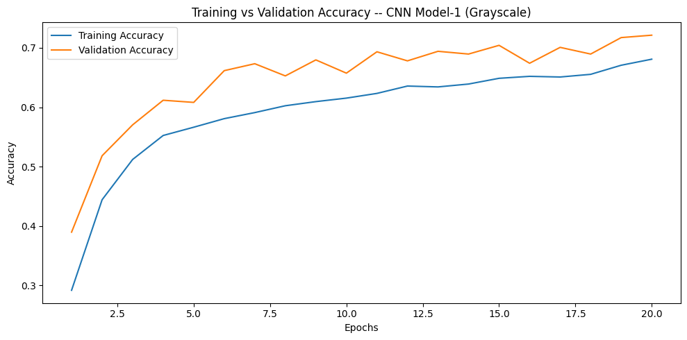

```python
# Plot training history accuracies
plt.figure(figsize=(10, 5))
plt.plot(epochs_range, train_acc, label='Training Accuracy')
plt.plot(epochs_range, val_acc, label='Validation Accuracy')
plt.title('Training vs Validation Accuracy -- CNN Model-1 (Grayscale)')
plt.xlabel('Epochs')
plt.ylabel('Accuracy')
plt.legend()
plt.tight_layout()
plt.show()
```

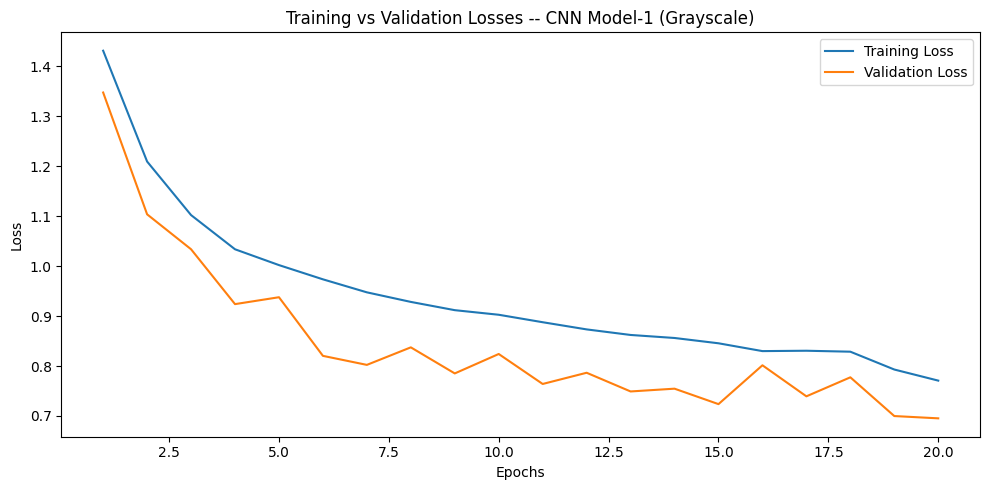

```python
# Plot training history losses
plt.figure(figsize=(10, 5))
plt.plot(epochs_range, train_loss, label='Training Loss')
plt.plot(epochs_range, val_loss, label='Validation Loss')
plt.title('Training vs Validation Losses -- CNN Model-1 (Grayscale)')
plt.xlabel('Epochs')
plt.ylabel('Loss')
plt.legend()
plt.tight_layout()
plt.show()
```

**Observations and Insights:__**

### **Creating the second Convolutional Neural Network**

- Try out a slightly larger architecture

```python
cnn_model_2 = Sequential([
    # Convolutional Layer-1
    Conv2D(64, (3, 3), activation='relu', input_shape=(IMG_SIZE, IMG_SIZE, 3), padding='same'),
    MaxPooling2D((2, 2)), # MaxPooling Layer

    # Convolutional Layer-2
    Conv2D(128, (3, 3), activation='relu', padding='same'),
    MaxPooling2D((2, 2)),

    # Convolutional Layer-3
    Conv2D(256, (3, 3), activation='relu', padding='same'),
    BatchNormalization(),
    MaxPooling2D((2, 2)),
    Dropout(0.2),  # Dropout layer to prevent overfitting

    # Convolutional Layer-4
    Conv2D(512, (3, 3), activation='relu', padding='same'),
    MaxPooling2D((2, 2)),
    Dropout(0.2),

    Flatten(),  # Flatten the output of the convolutional layers

    Dense(256, activation='relu'),  # Dense (fully connected) hidden layer
    Dense(128, activation='relu'),
    Dense(num_classes, activation='softmax')  # Output layer --> Classifier
])

# Model summary
cnn_model_2.summary()
```

```
Model: "sequential_15"
_________________________________________________________________
 Layer (type)                Output Shape              Param #
=================================================================
 conv2d_50 (Conv2D)          (None, 48, 48, 64)        1792

 max_pooling2d_50 (MaxPooli  (None, 24, 24, 64)        0
 ng2D)

 conv2d_51 (Conv2D)          (None, 24, 24, 128)       73856

 max_pooling2d_51 (MaxPooli  (None, 12, 12, 128)       0
 ng2D)

 conv2d_52 (Conv2D)          (None, 12, 12, 256)       295168

 batch_normalization_28 (Ba  (None, 12, 12, 256)       1024
 tchNormalization)

 max_pooling2d_52 (MaxPooli  (None, 6, 6, 256)         0
 ng2D)

 dropout_53 (Dropout)        (None, 6, 6, 256)         0

 conv2d_53 (Conv2D)          (None, 6, 6, 512)         1180160

 max_pooling2d_53 (MaxPooli  (None, 3, 3, 512)         0
 ng2D)

 dropout_54 (Dropout)        (None, 3, 3, 512)         0

 flatten_19 (Flatten)        (None, 4608)              0

 dense_53 (Dense)            (None, 256)               1179904

 dense_54 (Dense)            (None, 128)               32896

 dense_55 (Dense)            (None, 4)                 516

=================================================================
Total params: 2765316 (10.55 MB)
Trainable params: 2764804 (10.55 MB)
Non-trainable params: 512 (2.00 KB)
_________________________________________________________________
```

### **Compiling and Training the Model**

```python
# Creating a checkpoint which saves model weights from the best epoch
checkpoint = ModelCheckpoint("./cnn_model_2.h5", monitor='val_accuracy', verbose=1, save_best_only=True, mode='auto')

# Initiates early stopping if validation loss does not continue to improve
early_stopping = EarlyStopping(monitor = 'val_loss',
                          min_delta = 0,
                          patience = 6,
                          restore_best_weights = True
                          )

# Initiates reduced learning rate if validation loss does not continue to improve
reduce_learningrate = ReduceLROnPlateau(monitor = 'val_loss',
                              factor = 0.2,
                              patience = 3,
                              min_delta = 0.0001)

callbacks_list = [early_stopping, checkpoint, reduce_learningrate]
```

```python
# Compile the model
cnn_model_2.compile(optimizer=Adam(learning_rate=0.001), loss='categorical_crossentropy', metrics=['accuracy'])
```

```python
history_cnn2 = cnn_model_2.fit(
    train_generator_rgb,
    epochs=20,
    validation_data=validation_generator_rgb,
    callbacks=callbacks_list,
    verbose=1
)
```

```
Epoch 1: val_accuracy improved from -inf to 0.52100, saving model to ./cnn_model_2.h5
Epoch 2: val_accuracy improved from 0.52100 to 0.57484, saving model to ./cnn_model_2.h5
Epoch 3: val_accuracy improved from 0.57484 to 0.63050, saving model to ./cnn_model_2.h5
Epoch 4: val_accuracy improved from 0.63050 to 0.67993, saving model to ./cnn_model_2.h5
Epoch 5: val_accuracy did not improve from 0.67993
Epoch 6: val_accuracy did not improve from 0.67993
Epoch 7: val_accuracy improved from 0.67993 to 0.70223, saving model to ./cnn_model_2.h5
Epoch 8: val_accuracy improved from 0.70223 to 0.71027, saving model to ./cnn_model_2.h5
Epoch 9: val_accuracy improved from 0.71027 to 0.72072, saving model to ./cnn_model_2.h5
Epoch 10: val_accuracy did not improve from 0.72072
Epoch 11: val_accuracy improved from 0.72072 to 0.72433, saving model to ./cnn_model_2.h5
Epoch 12: val_accuracy did not improve from 0.72433
Epoch 13: val_accuracy did not improve from 0.72433
Epoch 14: val_accuracy improved from 0.72433 to 0.72815, saving model to ./cnn_model_2.h5
Epoch 15: val_accuracy did not improve from 0.72815
Epoch 16: val_accuracy did not improve from 0.72815
Epoch 17: val_accuracy did not improve from 0.72815
Epoch 18: val_accuracy improved from 0.72815 to 0.73157, saving model to ./cnn_model_2.h5
Epoch 19: val_accuracy improved from 0.73157 to 0.74161, saving model to ./cnn_model_2.h5
Epoch 20: val_accuracy improved from 0.74161 to 0.75105, saving model to ./cnn_model_2.h5
```

### **Evaluating the Model on the Test Set**

```python
# Evaluate the model on the test data (RGB)
print("Accuracy and Loss values -- Test Data")
cnn2_test_loss, cnn2_test_accuracy = cnn_model_2.evaluate(test_generator_rgb)
print(f'Test Accuracy: {cnn2_test_accuracy:.3f}, Test Loss: {cnn2_test_loss:.3f}')

# Evaluate the model on the validation data (RGB)
print("\nAccuracy and Loss values -- Validation Data")
cnn2_val_loss, cnn2_val_accuracy = cnn_model_2.evaluate(validation_generator_rgb)
print(f'Validation Accuracy: {cnn2_val_accuracy:.3f}, Validation Loss: {cnn2_val_loss:.3f}')
```

```
Accuracy and Loss values -- Test Data
Test Accuracy: 0.758, Test Loss: 0.597

Accuracy and Loss values -- Validation Data
Validation Accuracy: 0.751, Validation Loss: 0.672
```

```python
# Extract training and validation accuracy/loss from history
train_acc = history_cnn2.history['accuracy']
val_acc = history_cnn2.history['val_accuracy']

train_loss = history_cnn2.history['loss']
val_loss = history_cnn2.history['val_loss']

# Create epochs list
epochs_range = range(1, len(train_acc) + 1)
```

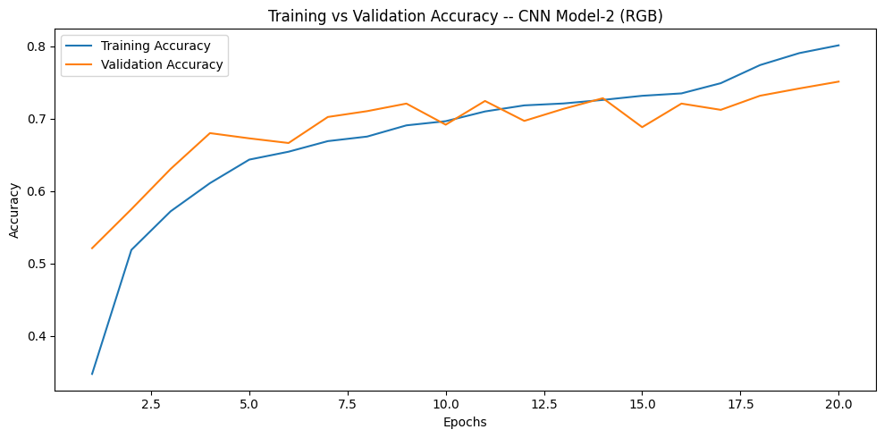

```python
# Plot training history accuracies
plt.figure(figsize=(10, 5))
plt.plot(epochs_range, train_acc, label='Training Accuracy')
plt.plot(epochs_range, val_acc, label='Validation Accuracy')
plt.title('Training vs Validation Accuracy -- CNN Model-2 (RGB)')
plt.xlabel('Epochs')
plt.ylabel('Accuracy')
plt.legend()
plt.tight_layout()
plt.show()
```

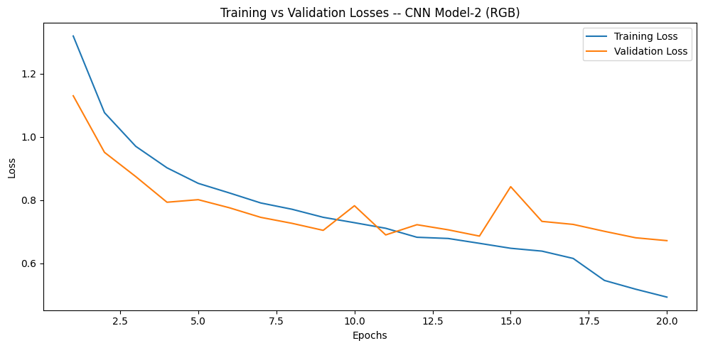

```python
# Plot training history losses
plt.figure(figsize=(10, 5))
plt.plot(epochs_range, train_loss, label='Training Loss')
plt.plot(epochs_range, val_loss, label='Validation Loss')
plt.title('Training vs Validation Losses -- CNN Model-2 (RGB)')
plt.xlabel('Epochs')
plt.ylabel('Loss')
plt.legend()
plt.tight_layout()
plt.show()
```

**Observations and Insights:__**

- The model performs better with time as the epochs increase.
- The model learning rate reduced at epoch-18 in an effort improve accuracy.
- The model doesn't seem to overfit as training accuracy trend doesn't deviate much from validation accuracy. However, we do see a change in the trend at epoch-14 to epoch-15 where training accuracy starts to grow more than validation accuracy and also at epoch-10 and epoch-15 (val_loss: 0.8423), we see that the validation loss seemed to spike but immediately got back to normal.
- Overall, CNN model-2 didn't performed bad even on RGB colored images but there is still room to improve as training accuracy started to grow more than validation accuracy at epoch-14; hence, adding drouput layers may help combat overfitting.
- In short, both models performed almost in a similar fashion although CNN Model-1 trained on "grayscale" was consistent and had overall better performance without any spikes or surprises.

## **Think About It:**

- Overall, CNN model-2 didn't performed bad even on RGB colored images but there is still room to improve as training accuracy started to grow more than validation accuracy at epoch-14; hence, adding drouput layers may help combat overfitting.
- Changing the input_shape from (48, 48, 1) to (48, 48, 3) didn;t have much impact or change.
- In short, both models performed almost in a similar fashion although CNN Model-1 trained on "grayscale" was consistent and had overall better performance without any spikes or surprises.

## **Transfer Learning Architectures**

### **Creating our Data Loaders for Transfer Learning Architectures**

In this section, we are creating data loaders that we will use as inputs to our Neural Network. We will have to go with color_mode = 'rgb' as this is the required format for the transfer learning architectures.

```python
# Data Augmentation
train_datagen = ImageDataGenerator(horizontal_flip = True,
                                                  brightness_range = (0.,2.),
                                                  rescale = 1./255,
                                                  zoom_range = 0.2,
                                                  shear_range = 0.3)
test_datagen = ImageDataGenerator(rescale = 1./255) # No data augmentation for test and/or validation data

# Image Generators -- Transfer Learning (RGB)
print("Colored Images -- Transfer Learning:")

train_generator = train_datagen.flow_from_directory(
    train_dir,
    target_size=(IMG_SIZE, IMG_SIZE),
    batch_size=32,
    color_mode='rgb',
    class_mode='categorical',
    seed = 42,
    shuffle=True
)

validation_generator = test_datagen.flow_from_directory(
    validation_dir,
    target_size=(IMG_SIZE, IMG_SIZE),
    batch_size=32,
    color_mode='rgb',
    class_mode='categorical',
    seed = 42,
    shuffle=False
)

test_generator = test_datagen.flow_from_directory(
    test_dir,
    target_size=(IMG_SIZE, IMG_SIZE),
    batch_size=32,
    color_mode='rgb',
    class_mode='categorical',
    seed = 42,
    shuffle=False
)


# Define the number of classes (emotions)
num_classes_tl = len(train_generator.class_indices)
print("\nNumber of training classes for Color Images:", num_classes_tl)
print("Class Indices for Color Images:", train_generator.class_indices)
```

```
Colored Images -- Transfer Learning:
Found 15109 images belonging to 4 classes.
Found 4977 images belonging to 4 classes.
Found 128 images belonging to 4 classes.

Number of training classes for Color Images: 4
Class Indices for Color Images: {'happy': 0, 'neutral': 1, 'sad': 2, 'surprise': 3}
```

## **VGG16 Model**

### **Importing the VGG16 Architecture**

```python
# Load the VGG16 Base Model
vgg_base_model = VGG16(weights='imagenet', include_top=False, input_shape=(IMG_SIZE, IMG_SIZE, 3))

# VGG16 base model summary output
vgg_base_model.summary()
```

```
Model: "vgg16"
_________________________________________________________________
 Layer (type)                Output Shape              Param #
=================================================================
 input_2 (InputLayer)        [(None, 48, 48, 3)]       0

 block1_conv1 (Conv2D)       (None, 48, 48, 64)        1792

 block1_conv2 (Conv2D)       (None, 48, 48, 64)        36928

 block1_pool (MaxPooling2D)  (None, 24, 24, 64)        0

 block2_conv1 (Conv2D)       (None, 24, 24, 128)       73856

 block2_conv2 (Conv2D)       (None, 24, 24, 128)       147584

 block2_pool (MaxPooling2D)  (None, 12, 12, 128)       0

 block3_conv1 (Conv2D)       (None, 12, 12, 256)       295168

 block3_conv2 (Conv2D)       (None, 12, 12, 256)       590080

 block3_conv3 (Conv2D)       (None, 12, 12, 256)       590080

 block3_pool (MaxPooling2D)  (None, 6, 6, 256)         0

 block4_conv1 (Conv2D)       (None, 6, 6, 512)         1180160

 block4_conv2 (Conv2D)       (None, 6, 6, 512)         2359808

 block4_conv3 (Conv2D)       (None, 6, 6, 512)         2359808

 block4_pool (MaxPooling2D)  (None, 3, 3, 512)         0

 block5_conv1 (Conv2D)       (None, 3, 3, 512)         2359808

 block5_conv2 (Conv2D)       (None, 3, 3, 512)         2359808

 block5_conv3 (Conv2D)       (None, 3, 3, 512)         2359808

 block5_pool (MaxPooling2D)  (None, 1, 1, 512)         0

=================================================================
Total params: 14714688 (56.13 MB)
Trainable params: 14714688 (56.13 MB)
Non-trainable params: 0 (0.00 Byte)
_________________________________________________________________
```

### **Model Building**

- Import VGG16 upto the layer of your choice and add Fully Connected layers on top of it.

```python
# Freeze the base model layers
for layer in vgg_base_model.layers:
    layer.trainable = False

# Add new fully connected layers on top of the base model
x_1 = vgg_base_model.output
x_1 = Flatten()(x_1)
x_1 = Dense(256, activation='relu')(x_1)
x_1 = Dropout(0.2)(x_1)
x_1 = Dense(128, activation='relu')(x_1)
x_1 = Dropout(0.2)(x_1)
x_1 = Dense(64, activation='relu')(x_1)
x_1 = BatchNormalization()(x_1)
outputs_vgg16 = Dense(num_classes_tl, activation='softmax')(x_1) # Classifier

# Create the final model
vgg16_model_1 = Model(inputs=vgg_base_model.input, outputs=outputs_vgg16)

# Model summary
vgg16_model_1.summary()
```

```
Model: "model_4"
_________________________________________________________________
 Layer (type)                Output Shape              Param #
=================================================================
 input_2 (InputLayer)        [(None, 48, 48, 3)]       0

 block1_conv1 (Conv2D)       (None, 48, 48, 64)        1792

 block1_conv2 (Conv2D)       (None, 48, 48, 64)        36928

 block1_pool (MaxPooling2D)  (None, 24, 24, 64)        0

 block2_conv1 (Conv2D)       (None, 24, 24, 128)       73856

 block2_conv2 (Conv2D)       (None, 24, 24, 128)       147584

 block2_pool (MaxPooling2D)  (None, 12, 12, 128)       0

 block3_conv1 (Conv2D)       (None, 12, 12, 256)       295168

 block3_conv2 (Conv2D)       (None, 12, 12, 256)       590080

 block3_conv3 (Conv2D)       (None, 12, 12, 256)       590080

 block3_pool (MaxPooling2D)  (None, 6, 6, 256)         0

 block4_conv1 (Conv2D)       (None, 6, 6, 512)         1180160

 block4_conv2 (Conv2D)       (None, 6, 6, 512)         2359808

 block4_conv3 (Conv2D)       (None, 6, 6, 512)         2359808

 block4_pool (MaxPooling2D)  (None, 3, 3, 512)         0

 block5_conv1 (Conv2D)       (None, 3, 3, 512)         2359808

 block5_conv2 (Conv2D)       (None, 3, 3, 512)         2359808

 block5_conv3 (Conv2D)       (None, 3, 3, 512)         2359808

```

[output cut: 9 more lines]

```

 dropout_18 (Dropout)        (None, 128)               0

 dense_32 (Dense)            (None, 64)                8256

 batch_normalization_4 (Bat  (None, 64)                256
 chNormalization)

 dense_33 (Dense)            (None, 4)                 260

=================================================================
Total params: 14887684 (56.79 MB)
Trainable params: 172868 (675.27 KB)
Non-trainable params: 14714816 (56.13 MB)
_________________________________________________________________
```

### **Compiling and Training the VGG16 Model**

```python
# Compile the new VGG16 model
vgg16_model_1.compile(optimizer=Adam(learning_rate = 0.001), loss='categorical_crossentropy', metrics=['accuracy'])
```

```python
# Creating a checkpoint which saves model weights from the best epoch
checkpoint = ModelCheckpoint('./vgg16_model_1.h5', monitor='val_accuracy', verbose=1, save_best_only=True, mode='auto')

# Initiates early stopping if validation loss does not continue to improve
early_stopping = EarlyStopping(monitor = 'val_loss',
                              min_delta = 0,
                              patience = 15,  # Increase the value so that model doesn't stop early
                              restore_best_weights = True)

# Initiates reduced learning rate if validation loss does not continue to improve
reduce_learningrate = ReduceLROnPlateau(monitor = 'val_loss',
                                        factor = 0.2,
                                        patience = 3,
                                        min_delta = 0.0001)

callbacks_list = [checkpoint, early_stopping, reduce_learningrate]
```

```python
# Train the new VGG16 model (RGB)
history_vgg16 = vgg16_model_1.fit (
    train_generator,
    epochs=20,
    validation_data=validation_generator,
    verbose=1,
    callbacks=callbacks_list
)
```

```
Epoch 1: val_accuracy improved from -inf to 0.48403, saving model to ./vgg16_model_1.h5
Epoch 2: val_accuracy improved from 0.48403 to 0.51236, saving model to ./vgg16_model_1.h5
Epoch 3: val_accuracy improved from 0.51236 to 0.51597, saving model to ./vgg16_model_1.h5
Epoch 4: val_accuracy improved from 0.51597 to 0.52602, saving model to ./vgg16_model_1.h5
Epoch 5: val_accuracy did not improve from 0.52602
Epoch 6: val_accuracy improved from 0.52602 to 0.53325, saving model to ./vgg16_model_1.h5
Epoch 7: val_accuracy did not improve from 0.53325
Epoch 8: val_accuracy did not improve from 0.53325
Epoch 9: val_accuracy did not improve from 0.53325
Epoch 10: val_accuracy improved from 0.53325 to 0.53988, saving model to ./vgg16_model_1.h5
Epoch 11: val_accuracy did not improve from 0.53988
Epoch 12: val_accuracy did not improve from 0.53988
Epoch 13: val_accuracy did not improve from 0.53988
Epoch 14: val_accuracy improved from 0.53988 to 0.54149, saving model to ./vgg16_model_1.h5
Epoch 15: val_accuracy did not improve from 0.54149
Epoch 16: val_accuracy improved from 0.54149 to 0.54250, saving model to ./vgg16_model_1.h5
Epoch 17: val_accuracy improved from 0.54250 to 0.54370, saving model to ./vgg16_model_1.h5
Epoch 18: val_accuracy did not improve from 0.54370
Epoch 19: val_accuracy improved from 0.54370 to 0.54450, saving model to ./vgg16_model_1.h5
Epoch 20: val_accuracy did not improve from 0.54450
```

### **Evaluating the VGG16 model**

```python
# Evaluate the model on the test data (RGB)
print("Accuracy and Loss values -- Test Data")
vgg16_test_loss, vgg16_test_accuracy = vgg16_model_1.evaluate(test_generator)
print(f'Test Accuracy: {vgg16_test_accuracy:.3f}, Test Loss: {vgg16_test_loss:.3f}')

# Evaluate the model on the validation data (RGB)
print("\nAccuracy and Loss values -- Validation Data")
vgg16_val_loss, vgg16_val_accuracy = vgg16_model_1.evaluate(validation_generator)
print(f'Validation Accuracy: {vgg16_val_accuracy:.3f}, Validation Loss: {vgg16_val_loss:.3f}')
```

```
Accuracy and Loss values -- Test Data
Test Accuracy: 0.484, Test Loss: 1.087

Accuracy and Loss values -- Validation Data
Validation Accuracy: 0.544, Validation Loss: 1.054
```

```python
# Extract training and validation accuracy/loss from history
train_acc = history_vgg16.history['accuracy']
val_acc = history_vgg16.history['val_accuracy']

train_loss = history_vgg16.history['loss']
val_loss = history_vgg16.history['val_loss']

# Create range of epochs
epochs_range = range(1, len(train_acc) + 1)
```

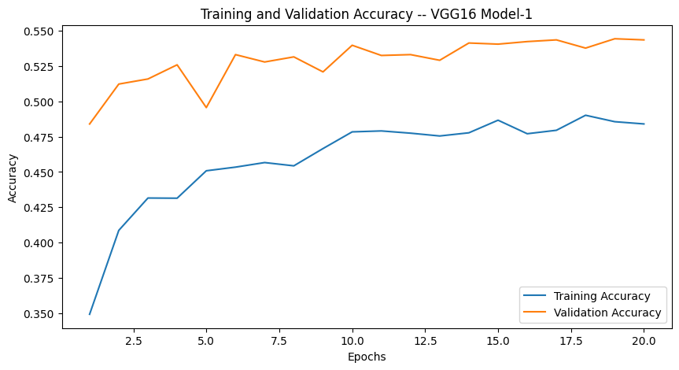

```python
# Plot training and validation accuracy
plt.figure(figsize=(10, 5))
plt.plot(epochs_range, train_acc, label='Training Accuracy')
plt.plot(epochs_range, val_acc, label='Validation Accuracy')
plt.title('Training and Validation Accuracy -- VGG16 Model-1')
plt.xlabel('Epochs')
plt.ylabel('Accuracy')
plt.legend()
plt.tight_layout
plt.show()
```

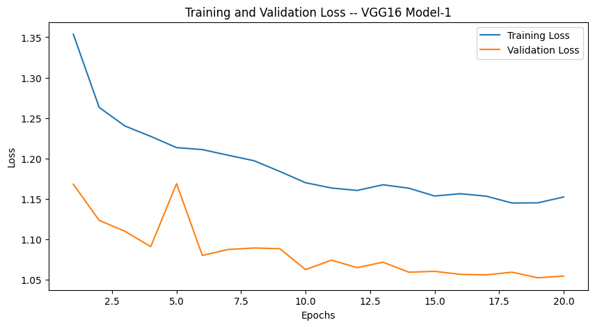

```python
# Plot training and validation loss
plt.figure(figsize=(10, 5))
plt.plot(epochs_range, train_loss, label='Training Loss')
plt.plot(epochs_range, val_loss, label='Validation Loss')
plt.title('Training and Validation Loss -- VGG16 Model-1')
plt.xlabel('Epochs')
plt.ylabel('Loss')
plt.legend()
plt.tight_layout
plt.show()
```

**Think About It:**

- What do you infer from the general trend in the training performance?
- Is the training accuracy consistently improving?
- Is the validation accuracy also improving similarly?

**Observations and Insights:__**

- The Model didn't show much better accuracies and losses than previous CNN Model-1 and CNN Model-2.
- The model reduced learning rate at early stage around at epoch-10 and then later on epoch-14 trying to improve the accuracies but they didn't improve much (increase was from 0.521 to 0.543)
- This model doesn't really perform better with this dataset and also accuracies and losses for both training and validation are'nt that close a they were during previous CNN Models.
- Perhaps, VGG16 model performs better at a bit larger image pixel sizes and also at actual colored images than on grayscale images.

**Note: You can even go back and build your own architecture on top of the VGG16 Transfer layer and see if you can improve the performance**

## **ResNet V2 Model**

```python
# Load pre-trained ResNet50V2 model without the top layers
resnet_base_model = ResNet50V2(weights='imagenet', include_top=False, input_shape=(IMG_SIZE, IMG_SIZE, 3))
resnet_base_model.summary()
```

```
Downloading data from https://storage.googleapis.com/tensorflow/keras-applications/resnet/resnet50v2_weights_tf_dim_ordering_tf_kernels_notop.h5
Model: "resnet50v2"
__________________________________________________________________________________________________
 Layer (type)                Output Shape                 Param #   Connected to
==================================================================================================
 input_3 (InputLayer)        [(None, 48, 48, 3)]          0         []

 conv1_pad (ZeroPadding2D)   (None, 54, 54, 3)            0         ['input_3[0][0]']

 conv1_conv (Conv2D)         (None, 24, 24, 64)           9472      ['conv1_pad[0][0]']

 pool1_pad (ZeroPadding2D)   (None, 26, 26, 64)           0         ['conv1_conv[0][0]']

 pool1_pool (MaxPooling2D)   (None, 12, 12, 64)           0         ['pool1_pad[0][0]']

 conv2_block1_preact_bn (Ba  (None, 12, 12, 64)           256       ['pool1_pool[0][0]']
 tchNormalization)

 conv2_block1_preact_relu (  (None, 12, 12, 64)           0         ['conv2_block1_preact_bn[0][0]
 Activation)                                                        ']

 conv2_block1_1_conv (Conv2  (None, 12, 12, 64)           4096      ['conv2_block1_preact_relu[0][
 D)                                                                 0]']

 conv2_block1_1_bn (BatchNo  (None, 12, 12, 64)           256       ['conv2_block1_1_conv[0][0]']
 rmalization)

 conv2_block1_1_relu (Activ  (None, 12, 12, 64)           0         ['conv2_block1_1_bn[0][0]']
 ation)

 conv2_block1_2_pad (ZeroPa  (None, 14, 14, 64)           0         ['conv2_block1_1_relu[0][0]']
 dding2D)

 conv2_block1_2_conv (Conv2  (None, 12, 12, 64)           36864     ['conv2_block1_2_pad[0][0]']
 D)

 conv2_block1_2_bn (BatchNo  (None, 12, 12, 64)           256       ['conv2_block1_2_conv[0][0]']
 rmalization)

 conv2_block1_2_relu (Activ  (None, 12, 12, 64)           0         ['conv2_block1_2_bn[0][0]']
```

[output cut: 519 more lines]

```
 D)

 conv5_block3_out (Add)      (None, 2, 2, 2048)           0         ['conv5_block2_out[0][0]',
                                                                     'conv5_block3_3_conv[0][0]']

 post_bn (BatchNormalizatio  (None, 2, 2, 2048)           8192      ['conv5_block3_out[0][0]']
 n)

 post_relu (Activation)      (None, 2, 2, 2048)           0         ['post_bn[0][0]']

==================================================================================================
Total params: 23564800 (89.89 MB)
Trainable params: 23519360 (89.72 MB)
Non-trainable params: 45440 (177.50 KB)
__________________________________________________________________________________________________
```

### **Model Building**

- Import Resnet v2 upto the layer of your choice and add Fully Connected layers on top of it.

```python
# Freeze the base model layers (don't train these pre-trained weights)
for layer in resnet_base_model.layers:
  layer.trainable = False

# Add new layers for classification specific to your emotions
x_2 = resnet_base_model.output
x_2 = Flatten()(x_2)
x_2 = Dense(256, activation='relu')(x_2)
x_2 = Dropout(0.2)(x_2)
x_2 = Dense(128, activation='relu')(x_2)
x_2 = Dropout(0.2)(x_2)
x_2 = Dense(64, activation='relu')(x_2)
x_2 = BatchNormalization()(x_2)
outputs_resnet = Dense(num_classes_tl, activation='softmax')(x_2)  # Output layer with softmax for multi-class classification

# Create the final model
resnet_model_1 = Model(inputs=resnet_base_model.input, outputs=outputs_resnet)

# Model summary
resnet_model_1.summary()
```

```
Model: "model_5"
__________________________________________________________________________________________________
 Layer (type)                Output Shape                 Param #   Connected to
==================================================================================================
 input_3 (InputLayer)        [(None, 48, 48, 3)]          0         []

 conv1_pad (ZeroPadding2D)   (None, 54, 54, 3)            0         ['input_3[0][0]']

 conv1_conv (Conv2D)         (None, 24, 24, 64)           9472      ['conv1_pad[0][0]']

 pool1_pad (ZeroPadding2D)   (None, 26, 26, 64)           0         ['conv1_conv[0][0]']

 pool1_pool (MaxPooling2D)   (None, 12, 12, 64)           0         ['pool1_pad[0][0]']

 conv2_block1_preact_bn (Ba  (None, 12, 12, 64)           256       ['pool1_pool[0][0]']
 tchNormalization)

 conv2_block1_preact_relu (  (None, 12, 12, 64)           0         ['conv2_block1_preact_bn[0][0]
 Activation)                                                        ']

 conv2_block1_1_conv (Conv2  (None, 12, 12, 64)           4096      ['conv2_block1_preact_relu[0][
 D)                                                                 0]']

 conv2_block1_1_bn (BatchNo  (None, 12, 12, 64)           256       ['conv2_block1_1_conv[0][0]']
 rmalization)

 conv2_block1_1_relu (Activ  (None, 12, 12, 64)           0         ['conv2_block1_1_bn[0][0]']
 ation)

 conv2_block1_2_pad (ZeroPa  (None, 14, 14, 64)           0         ['conv2_block1_1_relu[0][0]']
 dding2D)

 conv2_block1_2_conv (Conv2  (None, 12, 12, 64)           36864     ['conv2_block1_2_pad[0][0]']
 D)

 conv2_block1_2_bn (BatchNo  (None, 12, 12, 64)           256       ['conv2_block1_2_conv[0][0]']
 rmalization)

 conv2_block1_2_relu (Activ  (None, 12, 12, 64)           0         ['conv2_block1_2_bn[0][0]']
 ation)
```

[output cut: 536 more lines]

```
 dropout_20 (Dropout)        (None, 128)                  0         ['dense_35[0][0]']

 dense_36 (Dense)            (None, 64)                   8256      ['dropout_20[0][0]']

 batch_normalization_5 (Bat  (None, 64)                   256       ['dense_36[0][0]']
 chNormalization)

 dense_37 (Dense)            (None, 4)                    260       ['batch_normalization_5[0][0]'
                                                                    ]

==================================================================================================
Total params: 25703876 (98.05 MB)
Trainable params: 2138948 (8.16 MB)
Non-trainable params: 23564928 (89.89 MB)
__________________________________________________________________________________________________
```

### **Compiling and Training the Model**

```python
# Creating a checkpoint which saves model weights from the best epoch
checkpoint = ModelCheckpoint('./resnet_model_1.h5', monitor='val_accuracy', verbose=1, save_best_only=True, mode='auto')

# Initiates early stopping if validation loss does not continue to improve
early_stopping = EarlyStopping(monitor = 'val_loss',
                              min_delta = 0,
                              patience = 15,    # Increase so that model training doesn't cut off early
                              verbose = 1,
                              restore_best_weights = True)

# Initiates reduced learning rate if validation loss does not continue to improve
reduce_learningrate = ReduceLROnPlateau(monitor = 'val_loss',
                                        factor = 0.2,
                                        patience = 3,
                                        verbose = 1,
                                        min_delta = 0.0001)

callbacks_list = [checkpoint, early_stopping, reduce_learningrate]
```

```python
# Compile the model with an optimizer, loss function, and metrics
resnet_model_1.compile(optimizer=Adam(learning_rate = 0.001), loss='categorical_crossentropy', metrics=['accuracy'])
```

```python
# Train the model with training and validation data
history_resnet = resnet_model_1.fit (train_generator,
    epochs=20,
    validation_data=validation_generator,
    verbose=1,
    callbacks=callbacks_list
)
```

```
Epoch 1: val_accuracy improved from -inf to 0.49508, saving model to ./resnet_model_1.h5
Epoch 2: val_accuracy improved from 0.49508 to 0.53526, saving model to ./resnet_model_1.h5
Epoch 3: val_accuracy improved from 0.53526 to 0.53767, saving model to ./resnet_model_1.h5
Epoch 4: val_accuracy did not improve from 0.53767
Epoch 5: val_accuracy did not improve from 0.53767
Epoch 6: val_accuracy improved from 0.53767 to 0.56580, saving model to ./resnet_model_1.h5
Epoch 7: val_accuracy improved from 0.56580 to 0.57223, saving model to ./resnet_model_1.h5
Epoch 8: val_accuracy did not improve from 0.57223
Epoch 9: val_accuracy did not improve from 0.57223
Epoch 10: val_accuracy did not improve from 0.57223
Epoch 11: val_accuracy improved from 0.57223 to 0.57806, saving model to ./resnet_model_1.h5
Epoch 12: val_accuracy did not improve from 0.57806
Epoch 13: val_accuracy did not improve from 0.57806
Epoch 14: val_accuracy did not improve from 0.57806

Epoch 14: ReduceLROnPlateau reducing learning rate to 0.00020000000949949026.
Epoch 15: val_accuracy improved from 0.57806 to 0.58348, saving model to ./resnet_model_1.h5
Epoch 16: val_accuracy improved from 0.58348 to 0.59072, saving model to ./resnet_model_1.h5
Epoch 17: val_accuracy improved from 0.59072 to 0.59835, saving model to ./resnet_model_1.h5
Epoch 18: val_accuracy did not improve from 0.59835
Epoch 19: val_accuracy did not improve from 0.59835
Epoch 20: val_accuracy did not improve from 0.59835

Epoch 20: ReduceLROnPlateau reducing learning rate to 4.0000001899898055e-05.
```

### **Evaluating the ResNet Model**

```python
# Evaluate the model on the test data (RGB)
print("Accuracy and Loss values -- Test Data")
resnet_test_loss, resnet_test_accuracy = resnet_model_1.evaluate(test_generator)
print(f'Test Accuracy: {resnet_test_accuracy:.3f}, Test Loss: {resnet_test_loss:.3f}')

# Evaluate the model on the validation data (RGB)
print("\nAccuracy and Loss values -- Validation Data")
resnet_val_loss, resnet_val_accuracy = resnet_model_1.evaluate(validation_generator)
print(f'Validation Accuracy: {resnet_val_accuracy:.3f}, Validation Loss: {resnet_val_loss:.3f}')
```

```
Accuracy and Loss values -- Test Data
Test Accuracy: 0.539, Test Loss: 0.910

Accuracy and Loss values -- Validation Data
Validation Accuracy: 0.577, Validation Loss: 0.990
```

```python
# Extract training and validation accuracy/loss from history - for plotting and visualizing
train_acc = history_resnet.history['accuracy']
val_acc = history_resnet.history['val_accuracy']

train_loss = history_resnet.history['loss']
val_loss = history_resnet.history['val_loss']

# Create range of epochs
epochs_range = range(1, len(train_acc) + 1)
```

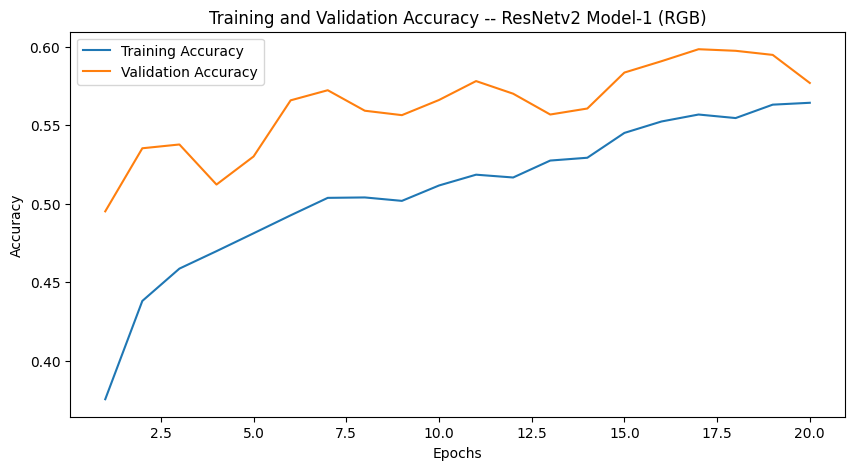

```python
# Plot training and validation accuracy (RGB)
plt.figure(figsize=(10, 5))
plt.plot(epochs_range, train_acc, label='Training Accuracy')
plt.plot(epochs_range, val_acc, label='Validation Accuracy')
plt.title('Training and Validation Accuracy -- ResNetv2 Model-1 (RGB)')
plt.xlabel('Epochs')
plt.ylabel('Accuracy')
plt.legend()
plt.tight_layout
plt.show()
```

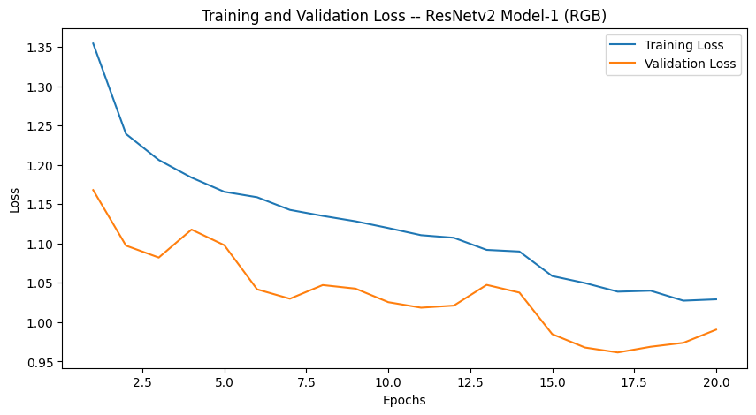

```python
# Plot training and validation loss (RGB)
plt.figure(figsize=(10, 5))
plt.plot(epochs_range, train_loss, label='Training Loss')
plt.plot(epochs_range, val_loss, label='Validation Loss')
plt.title('Training and Validation Loss -- ResNetv2 Model-1 (RGB)')
plt.xlabel('Epochs')
plt.ylabel('Loss')
plt.legend()
plt.tight_layout
plt.show()
```

**Observations and Insights:__**

- The Model didn't show much better accuracies and losses than previous CNN Model-1 and CNN Model-2.
- The model reduced learning rate at early stage around at epoch-15 trying to improve the accuracies but they didn't improve much.
- This model doesn't really perform better with this dataset but trend for both training and vlaidation remains smoother than VGG16 but overall accuracies and losses are not good (validation accuracy = 0.577).
- Actually, ResNetv2 model performs better at larger image pixel sizes as it expects **224 x 224** whereas we have **48 x 48** and also our actual images are not colored.

## **EfficientNet Model**

```python
# Load pre-trained EfficientNetV2 model without the top layers
efficient_base_model = EfficientNetV2B2(weights='imagenet', include_top=False, input_shape=(IMG_SIZE, IMG_SIZE, 3))
efficient_base_model.summary()
```

```
Downloading data from https://storage.googleapis.com/tensorflow/keras-applications/efficientnet_v2/efficientnetv2-b2_notop.h5
Model: "efficientnetv2-b2"
__________________________________________________________________________________________________
 Layer (type)                Output Shape                 Param #   Connected to
==================================================================================================
 input_1 (InputLayer)        [(None, 48, 48, 3)]          0         []

 rescaling (Rescaling)       (None, 48, 48, 3)            0         ['input_1[0][0]']

 normalization (Normalizati  (None, 48, 48, 3)            0         ['rescaling[0][0]']
 on)

 stem_conv (Conv2D)          (None, 24, 24, 32)           864       ['normalization[0][0]']

 stem_bn (BatchNormalizatio  (None, 24, 24, 32)           128       ['stem_conv[0][0]']
 n)

 stem_activation (Activatio  (None, 24, 24, 32)           0         ['stem_bn[0][0]']
 n)

 block1a_project_conv (Conv  (None, 24, 24, 16)           4608      ['stem_activation[0][0]']
 2D)

 block1a_project_bn (BatchN  (None, 24, 24, 16)           64        ['block1a_project_conv[0][0]']
 ormalization)

 block1a_project_activation  (None, 24, 24, 16)           0         ['block1a_project_bn[0][0]']
  (Activation)

 block1b_project_conv (Conv  (None, 24, 24, 16)           2304      ['block1a_project_activation[0
 2D)                                                                ][0]']

 block1b_project_bn (BatchN  (None, 24, 24, 16)           64        ['block1b_project_conv[0][0]']
 ormalization)

 block1b_project_activation  (None, 24, 24, 16)           0         ['block1b_project_bn[0][0]']
  (Activation)

 block1b_drop (Dropout)      (None, 24, 24, 16)           0         ['block1b_project_activation[0
                                                                    ][0]']
```

[output cut: 938 more lines]

```
                                                                     'block6i_add[0][0]']

 top_conv (Conv2D)           (None, 2, 2, 1408)           292864    ['block6j_add[0][0]']

 top_bn (BatchNormalization  (None, 2, 2, 1408)           5632      ['top_conv[0][0]']
 )

 top_activation (Activation  (None, 2, 2, 1408)           0         ['top_bn[0][0]']
 )

==================================================================================================
Total params: 8769374 (33.45 MB)
Trainable params: 8687086 (33.14 MB)
Non-trainable params: 82288 (321.44 KB)
__________________________________________________________________________________________________
```

### **Model Building**

- Import EfficientNet upto the layer of your choice and add Fully Connected layers on top of it.

```python
# Freeze the base model layers (don't train these pre-trained weights)
for layer in efficient_base_model.layers:
  layer.trainable = False

# Add new layers for classification specific to emotions
x_3 = efficient_base_model.output
x_3 = Flatten()(x_3)
x_3 = Dense(256, activation='relu')(x_3)
x_3 = Dropout(0.3)(x_3)
x_3 = Dense(128, activation='relu')(x_3)
x_3 = Dropout(0.4)(x_3)
x_3 = Dense(64, activation='relu')(x_3)
x_3 = BatchNormalization()(x_3)
outputs_efficient = Dense(num_classes_tl, activation='softmax')(x_3)  # Output layer

# Create the final model
efficient_model_1 = Model(inputs=efficient_base_model.input, outputs=outputs_efficient)

# Model summary
efficient_model_1.summary()
```

```
Model: "model_2"
__________________________________________________________________________________________________
 Layer (type)                Output Shape                 Param #   Connected to
==================================================================================================
 input_1 (InputLayer)        [(None, 48, 48, 3)]          0         []

 rescaling (Rescaling)       (None, 48, 48, 3)            0         ['input_1[0][0]']

 normalization (Normalizati  (None, 48, 48, 3)            0         ['rescaling[0][0]']
 on)

 stem_conv (Conv2D)          (None, 24, 24, 32)           864       ['normalization[0][0]']

 stem_bn (BatchNormalizatio  (None, 24, 24, 32)           128       ['stem_conv[0][0]']
 n)

 stem_activation (Activatio  (None, 24, 24, 32)           0         ['stem_bn[0][0]']
 n)

 block1a_project_conv (Conv  (None, 24, 24, 16)           4608      ['stem_activation[0][0]']
 2D)

 block1a_project_bn (BatchN  (None, 24, 24, 16)           64        ['block1a_project_conv[0][0]']
 ormalization)

 block1a_project_activation  (None, 24, 24, 16)           0         ['block1a_project_bn[0][0]']
  (Activation)

 block1b_project_conv (Conv  (None, 24, 24, 16)           2304      ['block1a_project_activation[0
 2D)                                                                ][0]']

 block1b_project_bn (BatchN  (None, 24, 24, 16)           64        ['block1b_project_conv[0][0]']
 ormalization)

 block1b_project_activation  (None, 24, 24, 16)           0         ['block1b_project_bn[0][0]']
  (Activation)

 block1b_drop (Dropout)      (None, 24, 24, 16)           0         ['block1b_project_activation[0
                                                                    ][0]']

```

[output cut: 955 more lines]

```
 dropout_19 (Dropout)        (None, 128)                  0         ['dense_22[0][0]']

 dense_23 (Dense)            (None, 64)                   8256      ['dropout_19[0][0]']

 batch_normalization_4 (Bat  (None, 64)                   256       ['dense_23[0][0]']
 chNormalization)

 dense_24 (Dense)            (None, 4)                    260       ['batch_normalization_4[0][0]'
                                                                    ]

==================================================================================================
Total params: 10253090 (39.11 MB)
Trainable params: 1483588 (5.66 MB)
Non-trainable params: 8769502 (33.45 MB)
__________________________________________________________________________________________________
```

### **Compiling and Training the Model**

```python
# Creating a checkpoint which saves model weights from the best epoch
checkpoint = ModelCheckpoint('./efficient_model_1.h5', monitor='val_accuracy', verbose=1, save_best_only=True, mode='auto')

# Initiates early stopping if validation loss does not continue to improve
early_stopping = EarlyStopping(monitor = 'val_loss',
                              min_delta = 0,
                              patience = 12,    # Increased over initial models otherwise training is cut off too quickly
                              verbose = 1,
                              restore_best_weights = True)

# Initiates reduced learning rate if validation loss does not continue to improve
reduce_learningrate = ReduceLROnPlateau(monitor = 'val_loss',
                                        factor = 0.2,
                                        patience = 3,
                                        verbose = 1,
                                        min_delta = 0.0001)

callbacks_list = [checkpoint, early_stopping, reduce_learningrate]
```

```python
# Compile the model with an optimizer, loss function, and metrics
efficient_model_1.compile(optimizer=Adam(learning_rate = 0.001), loss='categorical_crossentropy', metrics=['accuracy'])
```

```python
# Train the model with training and validation data
history_efficient = efficient_model_1.fit (train_generator,
    epochs=20,
    validation_data=validation_generator,
    verbose=1,
    callbacks=callbacks_list
)
```

[output not shown]

### **Evaluating the EfficientnetNet Model**

```python
# Evaluate the model on the test data (RGB)
print("Accuracy and Loss values -- Test Data")
efficient_test_loss, efficient_test_accuracy = efficient_model_1.evaluate(test_generator)
print(f'Test Accuracy: {efficient_test_accuracy:.3f}, Test Loss: {efficient_test_loss:.3f}')

# Evaluate the model on the validation data (RGB)
print("\nAccuracy and Loss values -- Validation Data")
efficient_val_loss, efficient_val_accuracy = efficient_model_1.evaluate(validation_generator)
print(f'Validation Accuracy: {efficient_val_accuracy:.3f}, Validation Loss: {efficient_val_loss:.3f}')
```

```
Accuracy and Loss values -- Test Data
Test Accuracy: 0.250, Test Loss: 1.393

Accuracy and Loss values -- Validation Data
Validation Accuracy: 0.367, Validation Loss: 1.365
```

```python
# Extract training and validation accuracy/loss from history - for plotting and visualizing
train_acc = history_efficient.history['accuracy']
val_acc = history_efficient.history['val_accuracy']

train_loss = history_efficient.history['loss']
val_loss = history_efficient.history['val_loss']

# Create range of epochs
epochs_range = range(1, len(train_acc) + 1)
```

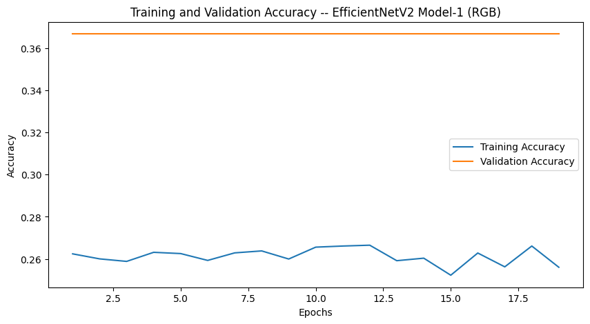

```python
# Plot training and validation accuracy (RGB)
plt.figure(figsize=(10, 5))
plt.plot(epochs_range, train_acc, label='Training Accuracy')
plt.plot(epochs_range, val_acc, label='Validation Accuracy')
plt.title('Training and Validation Accuracy -- EfficientNetV2 Model-1 (RGB)')
plt.xlabel('Epochs')
plt.ylabel('Accuracy')
plt.legend()
plt.tight_layout
plt.show()
```

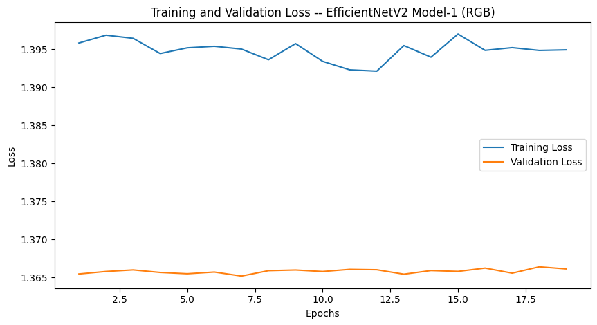

```python
# Plot training and validation loss (RGB)
plt.figure(figsize=(10, 5))
plt.plot(epochs_range, train_loss, label='Training Loss')
plt.plot(epochs_range, val_loss, label='Validation Loss')
plt.title('Training and Validation Loss -- EfficientNetV2 Model-1 (RGB)')
plt.xlabel('Epochs')
plt.ylabel('Loss')
plt.legend()
plt.tight_layout
plt.show()
```

**Observations and Insights:__**

**Think About It:**

- Overal performances of these Transfer Learning Acrhitecures are statisfactory and are poor.
- These models when imported have lot of parameters that are not suitable for our dataset that is a smaller dataset.
- These models are suitable for both bigger image pixel sizes and colored images whereas our dataset has 48 x 48 image pixel sizes and is grayscale.
- Previous CNN Models performed lot better than these models and had lower parameters and layers that are better suitable to our dataset than bigger pre-trained Transfer Learning Architecture models.

Let's see how complex CNN models peform in the next section but it seems they will perform better as we have seen previously with CNN Models.

Now that we have tried multiple pre-trained models, let's build a complex CNN architecture and see if we can get better performance.

## **Creating our Data Loaders**

In this section, we are creating data loaders which we will use as inputs to the more Complicated Convolutional Neural Network. We will go ahead with color_mode = 'grayscale'.

```python
# # Data augmentation
train_datagen = ImageDataGenerator(horizontal_flip = True,
                                                  brightness_range = (0.,2.),
                                                  rescale = 1./255,
                                                  zoom_range = 0.2,
                                                  rotation_range = 20,
                                                  shear_range = 0.3)
test_datagen = ImageDataGenerator(rescale = 1./255) # No data augmentation for test and/or validation

# Create image generators -- Grayscale Images
print("\nGrayscale Images:")

train_generator_gray = train_datagen.flow_from_directory(
    train_dir,
    target_size=(IMG_SIZE, IMG_SIZE),
    batch_size=32,
    color_mode='grayscale',
    class_mode='categorical',
    shuffle=True
)

validation_generator_gray = test_datagen.flow_from_directory(
    validation_dir,
    target_size=(IMG_SIZE, IMG_SIZE),
    batch_size=32,
    color_mode='grayscale',
    class_mode='categorical',
    shuffle=False
)

test_generator_gray = test_datagen.flow_from_directory(
    test_dir,
    target_size=(IMG_SIZE, IMG_SIZE),
    batch_size=32,
    color_mode='grayscale',
    class_mode='categorical',
    shuffle=False
)

# Define the number of classes (emotions)
num_classes_gray = len(train_generator_gray.class_indices)
print("\nNumber of training classes for Grayscale Images:", num_classes)
print("Training Class Indices for Grayscale Images:", train_generator_gray.class_indices)
```

```
Grayscale Images:
Found 15109 images belonging to 4 classes.
Found 4977 images belonging to 4 classes.
Found 128 images belonging to 4 classes.

Number of training classes for Grayscale Images: 4
Training Class Indices for Grayscale Images: {'happy': 0, 'neutral': 1, 'sad': 2, 'surprise': 3}
```

### **Model Building**

- Try building a layer with 5 Convolutional Blocks and see if performance increases.
- Let's change input shape to (48, 48, 1)

```python
# Define our first custome model with 5 Convolutional Blocks
complex_cnn_model_1 = Sequential([
  # Block 1
  Conv2D(32, (3, 3), activation='relu', input_shape= (IMG_SIZE, IMG_SIZE, 1), padding= 'same'),
  MaxPooling2D((2, 2)),
  # Block 2 (Let's add BatchNormalizatio, LeakyRelu, and GaussianNoise onwards)
  Conv2D(64, (3, 3), activation='relu', padding= 'same'),
  BatchNormalization(),
  LeakyReLU(alpha=0.1),
  MaxPooling2D((2, 2)),
  GaussianNoise(0.1),
  # Block 3
  Conv2D(128, (3, 3), activation='relu', padding= 'same'),
  BatchNormalization(),
  LeakyReLU(alpha=0.1),
  MaxPooling2D((2, 2)),
  Dropout(0.2), # Add dropout for regularization
  # Block 4
  Conv2D(256, (3, 3), activation='relu', padding= 'same'),
  BatchNormalization(),
  LeakyReLU(alpha=0.1),
  MaxPooling2D((2, 2)),
  GaussianNoise(0.1),
  # Block 5
  Conv2D(512, (3, 3), activation='relu', padding= 'same'),
  BatchNormalization(),
  LeakyReLU(alpha=0.1),
  MaxPooling2D((2, 2)),
  Dropout(0.2),
  # Flatten for dense layers
  Flatten(),
  # Dense layers for classification
  Dense(256, activation='relu'),
  BatchNormalization(),
  Dropout(0.2),
  # Add one more dense layer before output layer
  Dense(512, activation='relu'),
  BatchNormalization(),
  Dropout(0.2),
  Dense(num_classes_gray, activation='softmax')  # Output layer with softmax for multi-class classification
])

# Model summary
complex_cnn_model_1.summary()
```

```
Model: "sequential_27"
_________________________________________________________________
 Layer (type)                Output Shape              Param #
=================================================================
 conv2d_161 (Conv2D)         (None, 48, 48, 32)        320

 max_pooling2d_82 (MaxPooli  (None, 24, 24, 32)        0
 ng2D)

 conv2d_162 (Conv2D)         (None, 24, 24, 64)        18496

 batch_normalization_181 (B  (None, 24, 24, 64)        256
 atchNormalization)

 leaky_re_lu_144 (LeakyReLU  (None, 24, 24, 64)        0
 )

 max_pooling2d_83 (MaxPooli  (None, 12, 12, 64)        0
 ng2D)

 gaussian_noise_33 (Gaussia  (None, 12, 12, 64)        0
 nNoise)

 conv2d_163 (Conv2D)         (None, 12, 12, 128)       73856

 batch_normalization_182 (B  (None, 12, 12, 128)       512
 atchNormalization)

 leaky_re_lu_145 (LeakyReLU  (None, 12, 12, 128)       0
 )

 max_pooling2d_84 (MaxPooli  (None, 6, 6, 128)         0
 ng2D)

 dropout_182 (Dropout)       (None, 6, 6, 128)         0

 conv2d_164 (Conv2D)         (None, 6, 6, 256)         295168

 batch_normalization_183 (B  (None, 6, 6, 256)         1024
 atchNormalization)
```

[output cut: 31 more lines]

```

 dense_82 (Dense)            (None, 512)               131584

 batch_normalization_186 (B  (None, 512)               2048
 atchNormalization)

 dropout_185 (Dropout)       (None, 512)               0

 dense_83 (Dense)            (None, 4)                 2052

=================================================================
Total params: 1839876 (7.02 MB)
Trainable params: 1836420 (7.01 MB)
Non-trainable params: 3456 (13.50 KB)
_________________________________________________________________
```

### **Compiling and Training the Model**

```python
# Creating a checkpoint which saves model weights from the best epoch
checkpoint = ModelCheckpoint('./complex_cnn_model_1.h5', monitor='val_accuracy', verbose=1, save_best_only=True, mode='auto')

# Initiates early stopping if validation loss does not continue to improve
early_stopping = EarlyStopping(monitor = 'val_loss',
                              min_delta = 0,
                              patience = 10,
                              verbose = 1,
                              restore_best_weights = True)

# Initiates reduced learning rate if validation loss does not continue to improve
reduce_learningrate = ReduceLROnPlateau(monitor = 'val_loss',
                                        factor = 0.2,
                                        patience = 3,
                                        verbose = 1,
                                        min_delta = 0.0001)

callbacks_list = [checkpoint, early_stopping, reduce_learningrate]
```

```python
# Compile the model with an optimizer, loss function, and metrics
complex_cnn_model_1.compile(optimizer=Adam(learning_rate = 0.001), loss='categorical_crossentropy', metrics=['accuracy'])
```

```python
# Train the model with training and validation data
history_complex_cnn1 = complex_cnn_model_1.fit (train_generator_gray,
    epochs=30,
    validation_data=validation_generator_gray,
    verbose=1,
    callbacks=callbacks_list
)
```

```
Epoch 1: val_accuracy improved from -inf to 0.34740, saving model to ./complex_cnn_model_1.h5
Epoch 2: val_accuracy did not improve from 0.34740
Epoch 3: val_accuracy improved from 0.34740 to 0.44103, saving model to ./complex_cnn_model_1.h5
Epoch 4: val_accuracy improved from 0.44103 to 0.51999, saving model to ./complex_cnn_model_1.h5
Epoch 5: val_accuracy improved from 0.51999 to 0.58790, saving model to ./complex_cnn_model_1.h5
Epoch 6: val_accuracy improved from 0.58790 to 0.65461, saving model to ./complex_cnn_model_1.h5
Epoch 7: val_accuracy did not improve from 0.65461
Epoch 8: val_accuracy did not improve from 0.65461
Epoch 9: val_accuracy improved from 0.65461 to 0.67953, saving model to ./complex_cnn_model_1.h5
Epoch 10: val_accuracy did not improve from 0.67953
Epoch 11: val_accuracy improved from 0.67953 to 0.69741, saving model to ./complex_cnn_model_1.h5
Epoch 12: val_accuracy did not improve from 0.69741
Epoch 13: val_accuracy did not improve from 0.69741
Epoch 14: val_accuracy improved from 0.69741 to 0.71187, saving model to ./complex_cnn_model_1.h5
Epoch 15: val_accuracy did not improve from 0.71187
Epoch 16: val_accuracy improved from 0.71187 to 0.72775, saving model to ./complex_cnn_model_1.h5
Epoch 17: val_accuracy improved from 0.72775 to 0.74262, saving model to ./complex_cnn_model_1.h5
Epoch 18: val_accuracy did not improve from 0.74262
Epoch 19: val_accuracy did not improve from 0.74262
Epoch 20: val_accuracy did not improve from 0.74262

Epoch 20: ReduceLROnPlateau reducing learning rate to 0.00020000000949949026.
Epoch 21: val_accuracy improved from 0.74262 to 0.74844, saving model to ./complex_cnn_model_1.h5
Epoch 22: val_accuracy did not improve from 0.74844
Epoch 23: val_accuracy improved from 0.74844 to 0.75085, saving model to ./complex_cnn_model_1.h5
Epoch 24: val_accuracy improved from 0.75085 to 0.75648, saving model to ./complex_cnn_model_1.h5
Epoch 25: val_accuracy did not improve from 0.75648
Epoch 26: val_accuracy did not improve from 0.75648
Epoch 27: val_accuracy did not improve from 0.75648
Epoch 28: val_accuracy did not improve from 0.75648
Epoch 29: val_accuracy did not improve from 0.75648

Epoch 29: ReduceLROnPlateau reducing learning rate to 4.0000001899898055e-05.
Epoch 30: val_accuracy did not improve from 0.75648
```

### **Evaluating the Model on Test Set**

```python
# Evaluate the model on the test data (Grayscale)
print("Accuracy and Loss values -- Test Data")
complex1_test_loss, complex1_test_accuracy = complex_cnn_model_1.evaluate(test_generator_gray)
print(f'Test Accuracy: {complex1_test_accuracy:.3f}, Test Loss: {complex1_test_loss:.3f}')

# Evaluate the model on the validation data (Grayscale)
print("\nAccuracy and Loss values -- Validation Data")
complex1_val_loss, complex1_val_accuracy = complex_cnn_model_1.evaluate(validation_generator_gray)
print(f'Validation Accuracy: {complex1_val_accuracy:.3f}, Validation Loss: {complex1_val_loss:.3f}')
```

```
Accuracy and Loss values -- Test Data
Test Accuracy: 0.797, Test Loss: 0.555

Accuracy and Loss values -- Validation Data
Validation Accuracy: 0.755, Validation Loss: 0.604
```

```python
# Extract training and validation accuracy/loss from history - for plotting and visualizing
train_acc = history_complex_cnn1.history['accuracy']
val_acc = history_complex_cnn1.history['val_accuracy']

train_loss = history_complex_cnn1.history['loss']
val_loss = history_complex_cnn1.history['val_loss']

# Create range of epochs
epochs_range = range(1, len(train_acc) + 1)
```

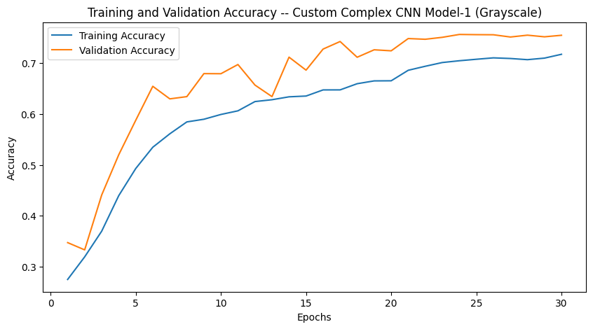

```python
# Plot training and validation accuracy
plt.figure(figsize=(10, 5))
plt.plot(epochs_range, train_acc, label='Training Accuracy')
plt.plot(epochs_range, val_acc, label='Validation Accuracy')
plt.title('Training and Validation Accuracy -- Custom Complex CNN Model-1 (Grayscale)')
plt.xlabel('Epochs')
plt.ylabel('Accuracy')
plt.legend()
plt.tight_layout
plt.show()
```

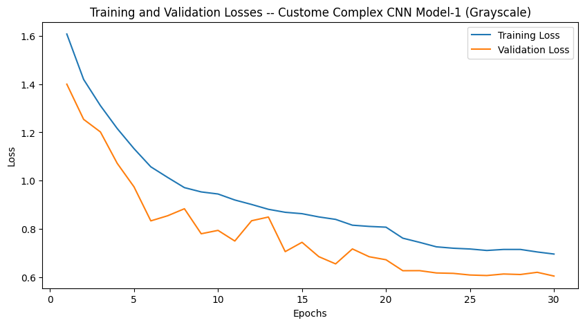

```python
# Plot training and validation losses
plt.figure(figsize=(10, 5))
plt.plot(epochs_range, train_loss, label='Training Loss')
plt.plot(epochs_range, val_loss, label='Validation Loss')
plt.title('Training and Validation Losses -- Custome Complex CNN Model-1 (Grayscale)')
plt.xlabel('Epochs')
plt.ylabel('Loss')
plt.legend()
plt.tight_layout
plt.show()
```

### **Model Building - Complex CNN Model-2**

- Let's build another custom Complex CNN Model for comparison sake and see if it performs the same or better than the first Complex CNN Model.
- We'll use the same data loaders as we did for first complex CNN model.
- Let's build it with 6 Convolutional Blocks along with 2 Dense layers before the output layer, change input_shape back to (48, 48, 1), for more epochs (40 epochs this time) and see how does new Complex CNN Model-2 perform.

```python
# Define our custom Complex CNN Model with 6 Convolutional Blocks
complex_cnn_model_2 = Sequential([
  # Block 1
  Conv2D(32, (3, 3), activation='relu', input_shape=(IMG_SIZE, IMG_SIZE, 1)),
  BatchNormalization(),
  LeakyReLU(alpha=0.1),
  MaxPooling2D((2, 2)),
  Dropout(0.2),

  # Block 2
  Conv2D(64, (3, 3), activation='relu'),
  BatchNormalization(),
  LeakyReLU(alpha=0.1),
  MaxPooling2D((2, 2)),
  Dropout(0.2),
  GaussianNoise(0.1),

  # Block 3
  Conv2D(128, (3, 3), activation='relu'),
  BatchNormalization(),
  LeakyReLU(alpha=0.1),
  Dropout(0.3),

  # Block 4 #
  Conv2D(256, (3, 3), activation='relu'),
  BatchNormalization(),
  LeakyReLU(alpha=0.1),
  Dropout(0.4),   # Increase dropout rate to combat overfitting
   # No downsampling in Block 4

  # Block 5
  Conv2D(512, (3, 3), activation='relu'),
  BatchNormalization(),
  LeakyReLU(alpha=0.1),
  Dropout(0.4),
  # No downsampling in Block 5

  # Block 6
  BatchNormalization(),
  Conv2D(256, (3, 3), kernel_regularizer=l2(0.025)),  # Add L2 regularization
  LeakyReLU(alpha=0.1),
  Dropout(0.3),
  BatchNormalization(),

  # Flatten for dense layers
  Flatten(),

  # Dense layers for classification
  Dense(512, activation='relu'),
  Dropout(0.2),
  GaussianNoise(0.1),  # Optional for data augmentation

  # Add one more dense layer before output layer
  Dense(256, activation='relu'),
  Dropout(0.2),
  Dense(num_classes_gray, activation='softmax')  # Output layer with softmax for multi-class classification
])

# Model summary
complex_cnn_model_2.summary()
```

```
Model: "sequential_26"
_________________________________________________________________
 Layer (type)                Output Shape              Param #
=================================================================
 conv2d_155 (Conv2D)         (None, 46, 46, 32)        320

 batch_normalization_174 (B  (None, 46, 46, 32)        128
 atchNormalization)

 leaky_re_lu_138 (LeakyReLU  (None, 46, 46, 32)        0
 )

 max_pooling2d_80 (MaxPooli  (None, 23, 23, 32)        0
 ng2D)

 dropout_174 (Dropout)       (None, 23, 23, 32)        0

 conv2d_156 (Conv2D)         (None, 21, 21, 64)        18496

 batch_normalization_175 (B  (None, 21, 21, 64)        256
 atchNormalization)

 leaky_re_lu_139 (LeakyReLU  (None, 21, 21, 64)        0
 )

 max_pooling2d_81 (MaxPooli  (None, 10, 10, 64)        0
 ng2D)

 dropout_175 (Dropout)       (None, 10, 10, 64)        0

 gaussian_noise_31 (Gaussia  (None, 10, 10, 64)        0
 nNoise)

 conv2d_157 (Conv2D)         (None, 8, 8, 128)         73856

 batch_normalization_176 (B  (None, 8, 8, 128)         512
 atchNormalization)

 leaky_re_lu_140 (LeakyReLU  (None, 8, 8, 128)         0
 )
```

[output cut: 41 more lines]

```

 gaussian_noise_32 (Gaussia  (None, 512)               0
 nNoise)

 dense_79 (Dense)            (None, 256)               131328

 dropout_181 (Dropout)       (None, 256)               0

 dense_80 (Dense)            (None, 4)                 1028

=================================================================
Total params: 3412100 (13.02 MB)
Trainable params: 3408580 (13.00 MB)
Non-trainable params: 3520 (13.75 KB)
_________________________________________________________________
```

### **Compiling and Training the Model** -- Complex CNN Model-2

```python
# Creating a checkpoint which saves model weights from the best epoch
checkpoint = ModelCheckpoint('./complex_cnn_model_2.h5', monitor='val_accuracy', verbose=1, save_best_only=True, mode='auto')

# Initiates early stopping if validation loss does not continue to improve
early_stopping = EarlyStopping(monitor = 'val_loss',
                              min_delta = 0,
                              patience = 10,
                              verbose = 1,
                              restore_best_weights = True)

# Initiates reduced learning rate if validation loss does not continue to improve
reduce_learningrate = ReduceLROnPlateau(monitor = 'val_loss',
                                        factor = 0.2,
                                        patience = 3,
                                        verbose = 1,
                                        min_delta = 0.0001)

callbacks_list = [checkpoint, early_stopping, reduce_learningrate]
```

```python
# Compile the model with an optimizer, loss function, and metrics
complex_cnn_model_2.compile(optimizer=Adam(learning_rate = 0.001), loss='categorical_crossentropy', metrics=['accuracy'])
```

```python
# Train the model with training and validation data
history_complex_cnn2 = complex_cnn_model_2.fit (train_generator_gray,
    epochs=40,
    validation_data=validation_generator_gray,
    verbose=1,
    callbacks=callbacks_list
)
```

```
Epoch 1: val_accuracy improved from -inf to 0.36729, saving model to ./complex_cnn_model_2.h5
Epoch 2: val_accuracy did not improve from 0.36729
Epoch 3: val_accuracy improved from 0.36729 to 0.41009, saving model to ./complex_cnn_model_2.h5
Epoch 4: val_accuracy improved from 0.41009 to 0.49568, saving model to ./complex_cnn_model_2.h5
Epoch 5: val_accuracy improved from 0.49568 to 0.54893, saving model to ./complex_cnn_model_2.h5
Epoch 6: val_accuracy improved from 0.54893 to 0.59875, saving model to ./complex_cnn_model_2.h5
Epoch 7: val_accuracy did not improve from 0.59875
Epoch 8: val_accuracy did not improve from 0.59875
Epoch 9: val_accuracy improved from 0.59875 to 0.63492, saving model to ./complex_cnn_model_2.h5
Epoch 10: val_accuracy did not improve from 0.63492
Epoch 11: val_accuracy did not improve from 0.63492
Epoch 12: val_accuracy improved from 0.63492 to 0.65803, saving model to ./complex_cnn_model_2.h5
Epoch 13: val_accuracy improved from 0.65803 to 0.69098, saving model to ./complex_cnn_model_2.h5
Epoch 14: val_accuracy did not improve from 0.69098
Epoch 15: val_accuracy did not improve from 0.69098
Epoch 16: val_accuracy did not improve from 0.69098
Epoch 17: val_accuracy improved from 0.69098 to 0.69359, saving model to ./complex_cnn_model_2.h5
Epoch 18: val_accuracy improved from 0.69359 to 0.69902, saving model to ./complex_cnn_model_2.h5

Epoch 18: ReduceLROnPlateau reducing learning rate to 0.00020000000949949026.
Epoch 19: val_accuracy improved from 0.69902 to 0.71871, saving model to ./complex_cnn_model_2.h5
Epoch 20: val_accuracy did not improve from 0.71871
Epoch 21: val_accuracy improved from 0.71871 to 0.72775, saving model to ./complex_cnn_model_2.h5
Epoch 22: val_accuracy did not improve from 0.72775
Epoch 23: val_accuracy did not improve from 0.72775
Epoch 24: val_accuracy did not improve from 0.72775
Epoch 25: val_accuracy improved from 0.72775 to 0.73056, saving model to ./complex_cnn_model_2.h5
Epoch 26: val_accuracy improved from 0.73056 to 0.73378, saving model to ./complex_cnn_model_2.h5
Epoch 27: val_accuracy did not improve from 0.73378
Epoch 28: val_accuracy improved from 0.73378 to 0.73920, saving model to ./complex_cnn_model_2.h5
Epoch 29: val_accuracy did not improve from 0.73920
Epoch 30: val_accuracy did not improve from 0.73920
Epoch 31: val_accuracy did not improve from 0.73920

Epoch 31: ReduceLROnPlateau reducing learning rate to 4.0000001899898055e-05.
Epoch 32: val_accuracy improved from 0.73920 to 0.73960, saving model to ./complex_cnn_model_2.h5
Epoch 33: val_accuracy improved from 0.73960 to 0.74503, saving model to ./complex_cnn_model_2.h5
Epoch 34: val_accuracy did not improve from 0.74503
Epoch 35: val_accuracy did not improve from 0.74503
Epoch 36: val_accuracy improved from 0.74503 to 0.74684, saving model to ./complex_cnn_model_2.h5
Epoch 37: val_accuracy did not improve from 0.74684
Epoch 38: val_accuracy improved from 0.74684 to 0.75105, saving model to ./complex_cnn_model_2.h5
Epoch 39: val_accuracy did not improve from 0.75105
Epoch 40: val_accuracy did not improve from 0.75105
```

### **Evaluating the Model on Test Set** -- Complex CNN Model-2

```python
# Evaluate the model on the test data (Grayscale)
print("Accuracy and Loss values -- Test Data")
complex2_test_loss, complex2_test_accuracy = complex_cnn_model_2.evaluate(test_generator_gray)
print(f'Test Accuracy: {complex2_test_accuracy:.3f}, Test Loss: {complex2_test_loss:.3f}')

# Evaluate the model on the validation data (Grayscale)
print("\nAccuracy and Loss values -- Validation Data")
complex2_val_loss, complex2_val_accuracy = complex_cnn_model_2.evaluate(validation_generator_gray)
print(f'Validation Accuracy: {complex2_val_accuracy:.3f}, Validation Loss: {complex2_val_loss:.3f}')
```

```
Accuracy and Loss values -- Test Data
Test Accuracy: 0.781, Test Loss: 0.622

Accuracy and Loss values -- Validation Data
Validation Accuracy: 0.743, Validation Loss: 0.676
```

```python
# Extract training and validation accuracy/loss from history - for plotting and visualizing
train_acc = history_complex_cnn2.history['accuracy']
val_acc = history_complex_cnn2.history['val_accuracy']

train_loss = history_complex_cnn2.history['loss']
val_loss = history_complex_cnn2.history['val_loss']

# Create range of epochs
epochs_range = range(1, len(train_acc) + 1)
```

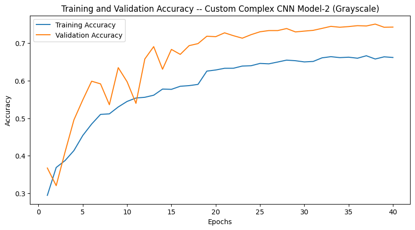

```python
# Plot training and validation accuracy
plt.figure(figsize=(10, 5))
plt.plot(epochs_range, train_acc, label='Training Accuracy')
plt.plot(epochs_range, val_acc, label='Validation Accuracy')
plt.title('Training and Validation Accuracy -- Custom Complex CNN Model-2 (Grayscale)')
plt.xlabel('Epochs')
plt.ylabel('Accuracy')
plt.legend()
plt.tight_layout
plt.show()
```

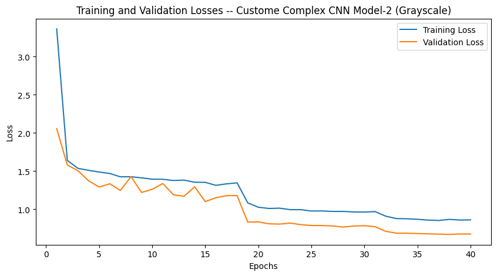

```python
# Plot training and validation losses
plt.figure(figsize=(10, 5))
plt.plot(epochs_range, train_loss, label='Training Loss')
plt.plot(epochs_range, val_loss, label='Validation Loss')
plt.title('Training and Validation Losses -- Custome Complex CNN Model-2 (Grayscale)')
plt.xlabel('Epochs')
plt.ylabel('Loss')
plt.legend()
plt.tight_layout
plt.show()
```

**Observations and Insights:__**

### **Plotting the Confusion Matrix for the chosen final model**

[output not shown]

[figure not shown]

```python
# Predict on validation data
predictions = complex_cnn_model_1.predict(validation_generator_gray)

# Convert predictions to class labels
predicted_classes = np.argmax(predictions, axis=1)

# Get true class labels from validation generator
true_classes = validation_generator_gray.classes

# Calculate confusion matrix
cm = confusion_matrix(true_classes, predicted_classes)

# Class names for the emotions
class_names = train_df['Emotions'].unique().tolist()

# Print classification report (optional)
print("\nClassification Report for Complex CNN Model-1 (Grayscale):")
print(classification_report(true_classes, predicted_classes, target_names=class_names))

# Function to plot the confusion matrix (optional)
def plot_confusion_matrix(cm, class_names):
  """
  Plots a confusion matrix with labels.
  """
  plt.figure(figsize=(8, 8))
  plt.imshow(cm, interpolation='nearest', cmap='Blues')
  plt.title('Confusion Matrix -- Complex CNN Model-1 (Grayscale)')
  plt.colorbar(shrink=0.5)
  tick_marks = np.arange(len(class_names))
  plt.xticks(tick_marks, class_names, rotation=45)
  plt.yticks(tick_marks, class_names)
  plt.tight_layout()
  plt.ylabel('True Class Label')
  plt.xlabel('Predicted Class Label')

  # Add counts as text on top of each block
  fmt = 'd'  # Integer format for counts
  thresh = cm.max() / 2.  # Threshold for color intensity
  for i in range(cm.shape[0]):
      for j in range(cm.shape[1]):
          plt.text(j, i, format(cm[i, j], fmt), ha="center", va="center",
                   color="white" if cm[i, j] > thresh else "black")
  plt.show()

# Plot the confusion matrix with counts on top
plot_confusion_matrix(cm, class_names)
```

**Observations and Insights:__**

## **Conclusion:*__***

**Summary of the Project:**

- We explored the task of grayscale image classification using deep learning techniques
- We compared the performance of seven different models, including CNNs and pre-trained models
- We found that the CNN Models performed much better than pre-trained models.And, complex_cnn_model_1 achieved the best accuracy.

**Achievements:**

- We successfully implemented and trained seven different models
- We analyzed the performance of each model and chose the best one
- We visualized the results and insights from the data

**Final thoughts:**

- This project demonstrates the effectiveness of deep learning techniques for image classification tasks
- The chosen model, complex_cnn_model_1, shows promising results and can be further improved with future work
- This project serves as a foundation for future exploration and innovation in the field of computer vision and deep learning.

### **Refined insights**:

**CNN Models:** Both traditional CNN models (cnn_model_1, cnn_model_2) and custom complex CNN models achieved good accuracy, demonstrating the effectiveness of convolutional layers in extracting features from facial images for emotion classification.

**Pre-trained Models (Mixed Results):** The performance of pre-trained models (VGG16, ResNet50V2, EfficientNetV2) varied. While they might not be directly optimized for facial emotions, they have the potential for improvement with fine-tuning specifically for this task.

**EfficientNetV2 Underperformed:** EfficientNetV2, known for efficiency in general image tasks, showed the lowest accuracy. This suggests that a more specialized architecture might be necessary for optimal facial emotion recognition.

**Impact of Model Complexity:** The complex CNN models (complex_cnn_model_1 and complex_cnn_model_2) with deeper architectures generally performed almost similar to simpler models. In our case there was slight improvement.

**Data Quality and Quantity:** The quality and quantity of your dataset can significantly impact model performance. Consider the representativeness of emotions, variations in facial features, and the number of images used for training. Data augmentation was applied in similar fashion to all the models and it didn't play a big role in driving models performance differences.

### **Overall Insights:**

**CNN Models are Promising:** For facial emotion recognition, deeper CNN architectures with proper techniques can achieve high accuracy.

**Potential of Fine-tuning Pre-trained Models:** Explore fine-tuning pre-trained models specifically for facial emotions to potentially improve performance beyond traditional CNNs.

**Importance of Dataset Quality:** High-quality and representative datasets are crucial for training effective and generalizable emotion recognition models.

### **Comparison of various techniques and their relative performance**:

Here's a breakdown of how different techniques performed in your facial emotion recognition project, along with potential for improvement:

[output not shown]

### **Improvement Strategies:**

**Hyperparameter Tuning:** Further optimize hyperparameters like learning rate, optimizer settings, and number of filters in convolutional layers for each model.

**Ensemble Learning:** Explore combining multiple models (e.g., complex_cnn_model_2 with a fine-tuned pre-trained model) through techniques like voting to potentially improve overall accuracy.

**Deeper Architectures (with Caution):** Experiment with even deeper CNN architectures, considering the trade-off between accuracy gains and computational resources.

**Data Augmentation Techniques:** Few techniques namely horizontal flip, image rescale, brightness range, shear and zoom range were applied. Perhaps, deeper data uagmentation technqiues can be explored to artificially increase the diversity of our training dataset.

**Fine-tuning Pre-trained Models:** If computational resources allow, fine-tune pre-trained models like VGG16 or ResNet50V2 specifically for our facial emotion recognition task.

### **Proposal for the final solution design**:

Based on the insights from the project, the proposed final solution design is **`complex_cnn_model_1`**. Here's why it's the best choice to adopt:

**Superior Performance:** Among all models explored, complex_cnn_model_1 achieved the highest accuracy in classifying facial expressions. This indicates its effectiveness in recognizing emotions from grayscale images.

Regularization and Normalization: This model incorporates regularization techniques (dropout) that help prevent overfitting and improve generalization. Additionally, incorporating mnormalization helped with faster convergence.

Here are some additional factors to consider:

**Computational Resources:** If computational resources are a significant constraint, consider a simpler model like cnn_model_1 with good accuracy while requiring less processing power.

**Further Improvement Potential:** If computational resources allow for further exploration, we can investigate fine-tuning pre-trained models specifically for facial emotions. This might potentially surpass the performance of CNN models.

Overall, complex_cnn_model_1 offers a strong balance between accuracy, efficiency, and the potential for further fine-tuning if needed. It's a well-suited solution for our facial emotion recognition project based on the explored models so far.